# Exercise 1

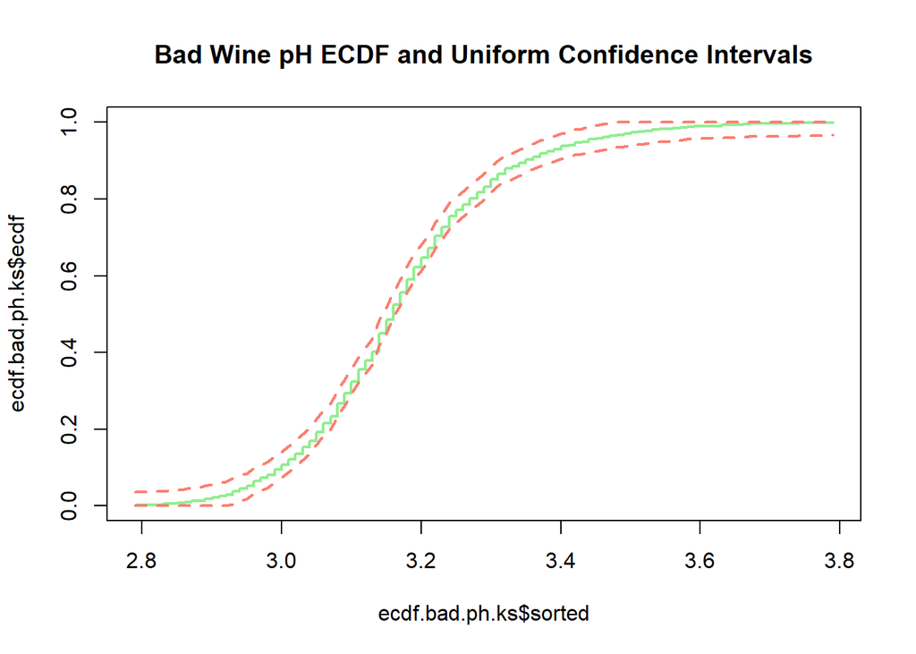

```r
ecdf.bad.ph.ks <- ecdf.ksbands(bad.wine$pH)

plot(ecdf.bad.ph.ks$sorted, ecdf.bad.ph.ks$ecdf,type = "s", col="lightgreen", lwd=2, main = "Bad Wine pH ECDF and Uniform Confidence Intervals")
lines(ecdf.bad.ph.ks$sorted, ecdf.bad.ph.ks$upper_bound, col="salmon", lwd=2, lty = "dashed")
lines(ecdf.bad.ph.ks$sorted, ecdf.bad.ph.ks$lower_bound, col="salmon", lwd=2, lty = "dashed")
```

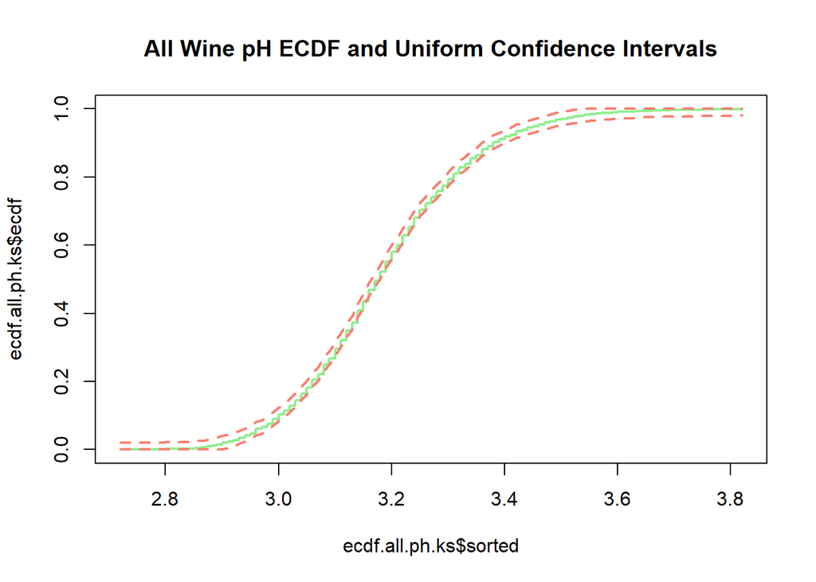

```r
ecdf.all.ph.ks <- ecdf.ksbands(white.wine.quality$pH)

plot(ecdf.all.ph.ks$sorted, ecdf.all.ph.ks$ecdf, type = "s", col="lightgreen", lwd=2, main = "All Wine pH ECDF and Uniform Confidence Intervals")
lines(ecdf.all.ph.ks$sorted, ecdf.all.ph.ks$upper_bound, col="salmon", lwd=2, lty = "dashed")
lines(ecdf.all.ph.ks$sorted, ecdf.all.ph.ks$lower_bound, col="salmon", lwd=2, lty = "dashed")
```

Kolmogorov-Smirnov bandwidth for sample size over 35 with 0.05 alpha value is [1.36/sqrt(N)](https://real-statistics.com/statistics-tables/kolmogorov-smirnov-table/) = 0.02382667. The problem with pointwise confidence intervals is, that if we compute them for a lot of points, we accumulate errors. Uniform confidence bands are slightly wider.

5- Plot the empirical distribution functions of pH for good and bad wines together with the uniform confidence bands in one plot. What can you conclude from this plot?

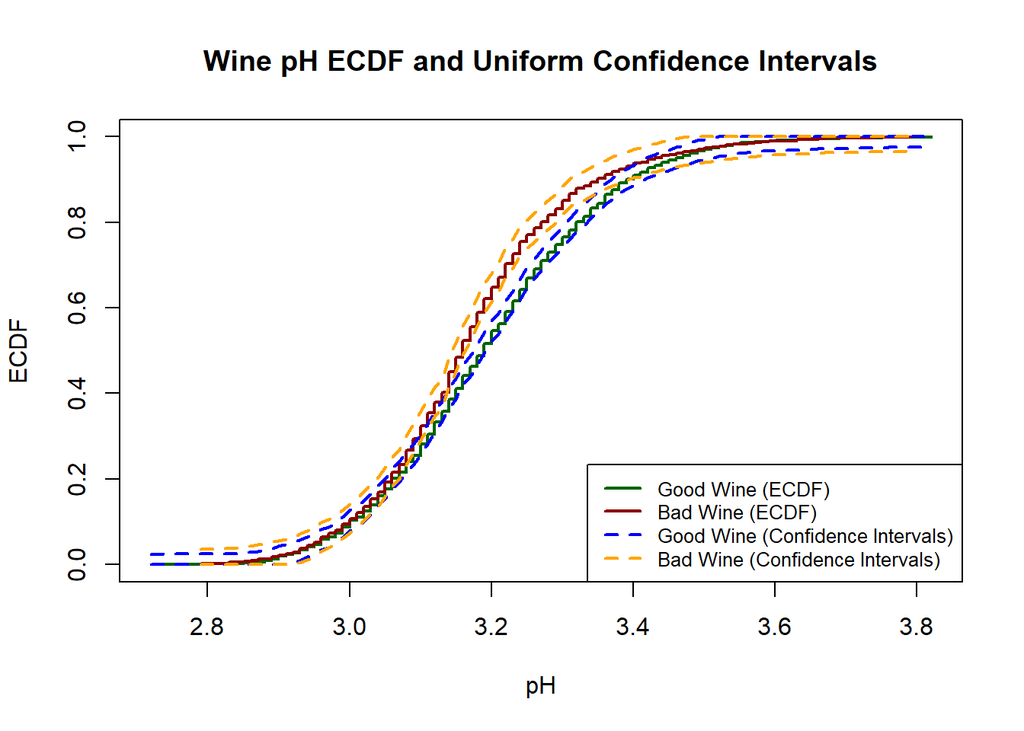

```r
# Create an empty plot with x-axis limits covering the range of both datasets

good_ph <- ecdf.ksbands(good.wine$pH)
bad_ph <- ecdf.ksbands(bad.wine$pH)

# Plot ECDFs for both good and bad wine pH in a single plot
plot(good_ph$sorted, good_ph$ecdf, type="s", col="darkgreen", lwd=2,
     main="Wine pH ECDF and Uniform Confidence Intervals", xlim = range(c(good.wine$pH, bad.wine$pH)), ylim = c(0, 1), ylab = "ECDF", xlab = "pH")

lines(bad_ph$sorted, bad_ph$ecdf, col="darkred", lwd=2, type="s")

# Add confidence intervals for good wine
lines(good_ph$sorted, good_ph$upper_bound, col="blue", lwd=2, lty = "dashed")
lines(good_ph$sorted, good_ph$lower_bound, col="blue", lwd=2, lty = "dashed")

# Add confidence intervals for bad wine
lines(bad_ph$sorted, bad_ph$upper_bound, col="orange", lwd=2, lty = "dashed")
lines(bad_ph$sorted, bad_ph$lower_bound, col="orange", lwd=2, lty = "dashed")

# Add a legend
legend("bottomright", legend=c("Good Wine (ECDF)", "Bad Wine (ECDF)", "Good Wine (Confidence Intervals)", "Bad Wine (Confidence Intervals)"),
       col=c("darkgreen", "darkred", "blue", "orange"), lwd=2, cex=0.8, lty=c("solid", "solid", "dashed", "dashed"))
```

On the ECDF we can see that up to a certain point, about to the pH value 3.1, good and bad wine pHs follow a similar distribution. Afterwards the gap increases as there are less bad wines with higher pH values. That is the pH of good wines is higher. Additionally, bad wines seem to have a larger confidence bands on tails compared to good wines.

## Maximum likelihood Estimation

Let X be Laplace distributed with parameters (µ, σ) t ∈ R × (0, ∞), i.e., X has density

$$f(x | \mu, σ) = \frac{1}{2σ}
\exp\left(-\frac{|x - \mu|}{σ}\right)$$

#### Exercises

1- Consider a sample of independent observations (X1, . . . , Xn). Show that the maximum likelihood estimator for µ is the median of the sample. Is it unique?

Check out this informative [blog](https://math.stackexchange.com/questions/240496/finding-the-maximum-likelihood-estimator).

Consider the likelihood function for N data samples:
$$L(\mu,\sigma;x) = \prod_{t=1}^{N}
\frac{1}{2\sigma} e^{-\frac{|x_t-\mu|}{\sigma}} = (2\sigma)^{-N}
e^{-\frac{1}{\sigma}\sum_{t=1}^{N}|x_t-\mu|}$$

Take the log likelihood function:

$$l(\mu,\sigma;x) = -N \ln(2\sigma) -
\frac{{1}}{\sigma} \sum_{t=1}^{N}|x_t-\mu|$$

Take the derivative with respect to the parameter $\mu$:
$$\frac{\partial l}{\partial \mu} = -\frac{1}{\sigma} \sum_{t=1}^{N}
\frac{\partial |x_t-\mu|}{\partial \mu}$$

which is equal to:
$$\frac{1}{\sigma} \sum_{t=1}^{N} \text{sgn}(x_t-\mu) = 0 \quad (1)$$

The sign function, usually denoted as $\text{sgn}(x)$, returns:
$$\text{sgn}(x) =
\begin{cases}
1 & \text{if } x > 0 \\
0 & \text{if } x = 0 \\
-1 & \text{if } x < 0
\end{cases}$$

2- Generate n = 20 independent realisations of X with µ = 1 and σ = 1. Determine the maximum likelihood estimator of µ based on this sample using R function quantile. Function quantile has 9 types of sample quantiles. Experiment with the different types of quantiles that are most suitable for the data (justify). Are there any differences? Increase now the sample to n = 1000 and compare different median estimators. Comment on the result.

```r
set.seed(123)

# Set parameters
mu <- 1
sigma <- 1

# Generate 20 independent realizations
n <- 20
laplace.data.20 <- rlaplace(n, mu, sigma)

for (i in 1:9) {
  cat("20 Samples Type ", i, " Median: ", quantile(laplace.data.20, 0.5, type = i), "\n")
}
```

```
## 20 Samples Type  1  Median:  0.6614653
## 20 Samples Type  2  Median:  0.6974013
## 20 Samples Type  3  Median:  0.6614653
## 20 Samples Type  4  Median:  0.6614653
## 20 Samples Type  5  Median:  0.6974013
## 20 Samples Type  6  Median:  0.6974013
## 20 Samples Type  7  Median:  0.6974013
## 20 Samples Type  8  Median:  0.6974013
## 20 Samples Type  9  Median:  0.6974013
```

```r
n <- 1000
laplace.data.1000 <- rlaplace(n, mu, sigma)

for (i in 1:9) {
  cat("1000 Samples Type ", i, " Median: ", quantile(laplace.data.1000, 0.5, type = i), "\n")
}
```

```
## 1000 Samples Type  1  Median:  0.9701096
## 1000 Samples Type  2  Median:  0.9701743
## 1000 Samples Type  3  Median:  0.9701096
## 1000 Samples Type  4  Median:  0.9701096
## 1000 Samples Type  5  Median:  0.9701743
## 1000 Samples Type  6  Median:  0.9701743
## 1000 Samples Type  7  Median:  0.9701743
## 1000 Samples Type  8  Median:  0.9701743
## 1000 Samples Type  9  Median:  0.9701743
```

To generate 20 independent realizations of a Laplace distribution with parameters µ = 1 and σ = 1 in R, you can use the rlaplace() function from the jmuOutlier package. They result in the same pattern. Type 1,3 and 4 are the same and the rest are another value. The reason for this is that for types 5 through 9, a different version of linear interpolation is applied. Type 4 is the linear interpolation of the empirical cdf. Type 2 averages at discontinuities and since we have even sample sizes and we are interested in the median, they all result in the same value. Therefore, type 1,3 and 4 rounds down and the rest takes the average of the 10th and 11th or the 500th and the 501st. In our case, type 2,5,6,7,8 and 9 can be used for an unbiased estimator. When comparing the results for n = 20 and n = 1000, you’ll notice that the medians are very close. This is expected because as the sample size increases, the sample median tends to converge to the population median, resulting in more consistent estimates regardless of the quantile type used.

3- Write your own function that calculates the maximum likelihood estimator for a Laplace sample numerically using R function optimise. Describe how R function optimise finds the maximum. Can you employ a Newton-Raphson algorithm for this problem? Generate n = 20 and n = 1000 independent realisations of X with µ = 1 and σ = 1. Calculate the maximum likelihood estimators based on both samples with your function and using quantile. Compare both estimators, comment on the results.

```r
laplace_data <- laplace.data.1000
  laplace.log.likelihood <- function(mu) {
    (-length(laplace_data)*log(2 *sigma) -(1/sigma) * sum(abs(laplace_data - mu)))
  }

optimise(laplace.log.likelihood,maximum = T,
         lower = 0, upper = 10)
```

```
## $maximum
## [1] 0.9701192
##
## $objective
## [1] -1422.881
```

```r
laplace_data <- laplace.data.20
optimise(laplace.log.likelihood,maximum = T,
         lower = 0, upper = 10)
```

```
## $maximum
## [1] 0.7205024
##
## $objective
## [1] -24.00157
```

According to the [documentation](https://www.rdocumentation.org/packages/stats/versions/3.6.2/topics/optimize), optimise() method uses somewhat a combination of golden section search and successive parabolic interpolation. The algorithm starts with an initial interval and evaluates the function at two points within this interval. The points are chosen according to the golden section ratio $φ = (1 + √5) / 2$, which ensures that the interval contracts efficiently. After the initial evaluations, the algorithm performs successive parabolic interpolations to refine the location of the maximum. This technique utilizes information from previous function evaluations to approximate the maximum more accurately. We get very close optimum results with the corresponding data.

Newton-Raphson method:
$$x_{k+1} = x_k -
Q_k$$
$$Q_k =
\frac{f'(x_k)}{f''(x_k)}$$

The problem with our function here is that, when we want to maximize the log likelihood, the second derivative of the function is not defined at the parameter µ and is 0 at other values. This makes the update step infinitely large so it is not possible to use Newton’s Method here.

4-) Let us now study the distribution of the maximum likelihood estimator. For this, calculate M = 5000 maximum likelihood estimators of µ based on the sample of n = 20 random variables generated from the Laplace distribution with µ = 1 and σ = 1. Repeat the same for the sample size n = 1000. Use histograms and QQ-plots to check if both Monte Carlo samples follow a normal distribution. Compare variances of both distributions, comment on the results.

```r
# Function to find MLE for mu using optimise
find_mle_laplace <- function(x) {
  result <- optimise(function(mu) laplace.log.likelihood(mu), maximum = TRUE, lower = -10, upper = 10)
  return(result$maximum)
}


# Parameters
mu <- 1
sigma <- 1
n <- 20
M <- 5000

# Storage for results
results_optimise <- numeric(M)
results_quantile <- numeric(M)

for (i in 1:M) {
  laplace_data <- rlaplace(n, mu, sigma)

  # Quantile (median)
  quantile_result <- quantile(laplace_data, 0.5, type = 5)
  results_quantile[i] <- quantile_result

  # MLE using optimise
  optimise_result <- find_mle_laplace(laplace_data)
  results_optimise[i] <- optimise_result

}

# Display results
cat("First 5 results using optimise:\n", head(results_optimise, 5), "\n")
```

```
## First 5 results using optimise:
##  0.9981306 0.9096638 0.953686 0.9714254 0.9626495
```

```r
cat("First 5 results using quantile:\n", head(results_quantile, 5), "\n")
```

```
## First 5 results using quantile:
##  0.9945633 0.9256988 0.9246251 0.924903 0.9595146
```

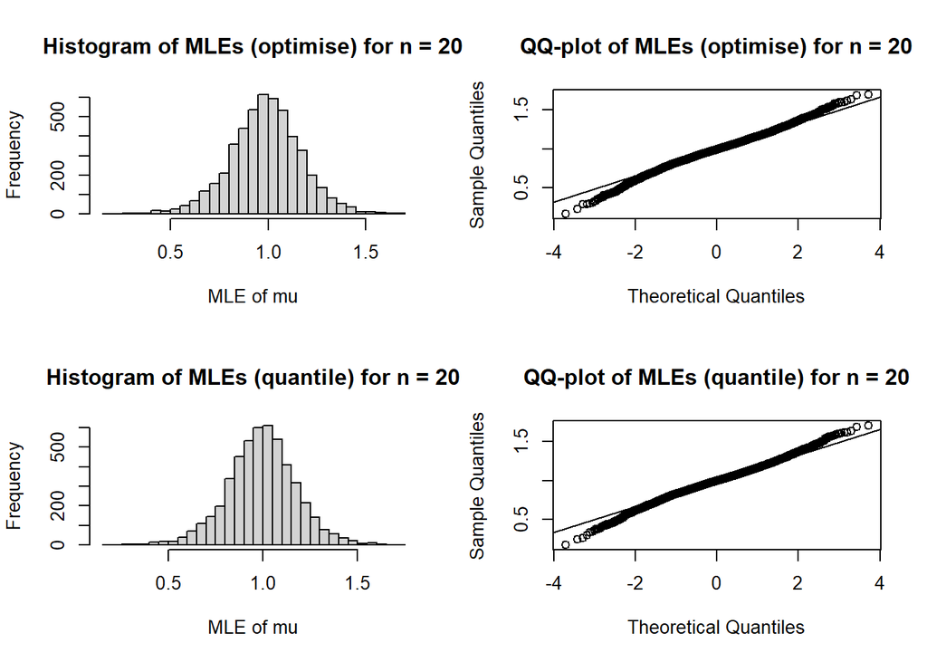

```r
# Plot histograms and QQ-plots
par(mfrow = c(2, 2))
hist(results_optimise, main = "Histogram of MLEs (optimise) for n = 20", xlab = "MLE of mu", breaks = 50)
qqnorm(results_optimise, main = "QQ-plot of MLEs (optimise) for n = 20")
qqline(results_optimise)

hist(results_quantile, main = "Histogram of MLEs (quantile) for n = 20", xlab = "MLE of mu", breaks = 50)
qqnorm(results_quantile, main = "QQ-plot of MLEs (quantile) for n = 20")
qqline(results_quantile)
```

```r
# Variance comparison
variance_optimise <- var(results_optimise)
variance_quantile <- var(results_quantile)

cat("Variance of MLEs using optimise for n = 20:", variance_optimise, "\n")
```

```
## Variance of MLEs using optimise for n = 20: 0.03324649
```

```r
cat("Variance of MLEs using quantile for n = 20:", variance_quantile, "\n")
```

```
## Variance of MLEs using quantile for n = 20: 0.03289854
```

```r
# n 1000
n = 1000

for (i in 1:M) {
  laplace_data <- rlaplace(n, mu, sigma)

  # Quantile (median)
  quantile_result <- quantile(laplace_data, 0.5, type = 5)
  results_quantile[i] <- quantile_result

  # MLE using optimise
  optimise_result <- find_mle_laplace(laplace_data)
  results_optimise[i] <- optimise_result

}

# Display results
cat("First 5 results using optimise:\n", head(results_optimise, 5), "\n")
```

```
## First 5 results using optimise:
##  0.9504666 0.9940443 0.9552063 1.011427 0.9975433
```

```r
cat("First 5 results using quantile:\n", head(results_quantile, 5), "\n")
```

```
## First 5 results using quantile:
##  0.950491 0.9940705 0.9551233 1.011644 0.9975928
```

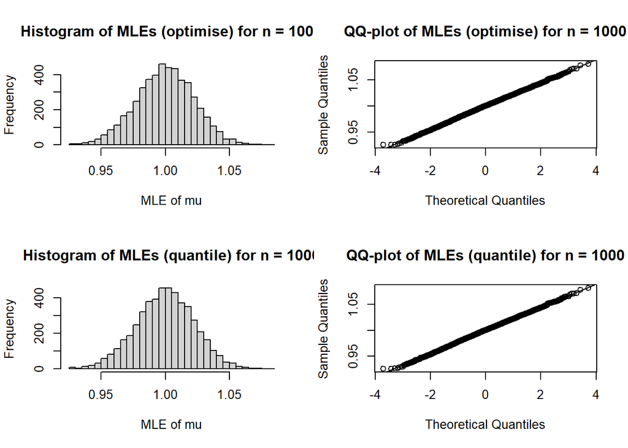

```r
# Plot histograms and QQ-plots
par(mfrow = c(2, 2))
hist(results_optimise, main = "Histogram of MLEs (optimise) for n = 1000", xlab = "MLE of mu", breaks = 50)
qqnorm(results_optimise, main = "QQ-plot of MLEs (optimise) for n = 1000")
qqline(results_optimise)

hist(results_quantile, main = "Histogram of MLEs (quantile) for n = 1000", xlab = "MLE of mu", breaks = 50)
qqnorm(results_quantile, main = "QQ-plot of MLEs (quantile) for n = 1000")
qqline(results_quantile)
```

```r
# Variance comparison
variance_optimise <- var(results_optimise)
variance_quantile <- var(results_quantile)

cat("Variance of MLEs using optimise for n = 1000:", variance_optimise, "\n")
```

```
## Variance of MLEs using optimise for n = 1000: 0.0005063235
```

```r
cat("Variance of MLEs using quantile for n = 1000:", variance_quantile, "\n")
```

```
## Variance of MLEs using quantile for n = 1000: 0.000506735
```

The variances are very close to each other, showing that both methods provide similar variability in the estimates for the larger sample size. As the sample size increases, the distribution of the MLEs tends to approximate the normal distribution more closely, which is consistent with the Central Limit Theorem. The variance of the MLEs decreases significantly as the sample size increases from 20 to 1000. This is expected since larger sample sizes provide more information about the population parameter, leading to more precise estimates.

## Linear Regression

#### Dataset

Go to Kaggle.com and download the data on house prices. This dataset contains house sale prices for King County, which includes Seattle. It includes homes sold between May 2014 and May 2015. There are altogether 19 variables, but we will consider in the analysis only the following ones:

- price: Price
- bedrooms: Number of bedrooms
- bathrooms: Number of bathrooms per bedroom
- sqft_living: Square footage of the home
- floors: Total floors in house
- view: Has been viewed (1 for viewed; 0 for not viewed)
- condition: How good is the condition (from 1 to 5)
- grade: Grade given to the housing unit based on King County grading system (from 1 to 13)
- yr_built: Year the house was built

```r
kc_house_data <- read.csv("archive/kc_house_data.csv")

kc_house_data <- kc_house_data %>%
  select(price, bedrooms, bathrooms,
         sqft_living,
         floors,
         view,
         condition,
         grade,
         yr_built)

head(kc_house_data)
```

```
##     price bedrooms bathrooms sqft_living floors view condition grade yr_built
## 1  221900        3      1.00        1180      1    0         3     7     1955
## 2  538000        3      2.25        2570      2    0         3     7     1951
## 3  180000        2      1.00         770      1    0         3     6     1933
## 4  604000        4      3.00        1960      1    0         5     7     1965
## 5  510000        3      2.00        1680      1    0         3     8     1987
## 6 1225000        4      4.50        5420      1    0         3    11     2001
```

#### Exercises

1-) Estimate a linear model with the response variable price and all remaining variables as covariates. Are all variables significant? How large is R2 and how can this be interpreted? Perform the residual analysis to validate the model. Are there any departures from the linear regression model assumptions?

```r
model <- lm(price ~ bedrooms + bathrooms + sqft_living + floors + view + condition + grade + yr_built, data = kc_house_data)

summary(model)
```

```
##
## Call:
## lm(formula = price ~ bedrooms + bathrooms + sqft_living + floors +
##     view + condition + grade + yr_built, data = kc_house_data)
##
## Residuals:
##      Min       1Q   Median       3Q      Max
## -1337280  -111873   -10359    90133  4470268
##
## Coefficients:
##               Estimate Std. Error t value Pr(>|t|)
## (Intercept)  6.356e+06  1.326e+05  47.950  < 2e-16 ***
## bedrooms    -4.065e+04  2.066e+03 -19.671  < 2e-16 ***
## bathrooms    4.769e+04  3.487e+03  13.677  < 2e-16 ***
## sqft_living  1.693e+02  3.307e+00  51.199  < 2e-16 ***
## floors       2.832e+04  3.496e+03   8.101 5.72e-16 ***
## view         7.138e+04  2.107e+03  33.885  < 2e-16 ***
## condition    1.815e+04  2.519e+03   7.205 6.01e-13 ***
## grade        1.228e+05  2.187e+03  56.160  < 2e-16 ***
## yr_built    -3.650e+03  6.824e+01 -53.484  < 2e-16 ***
## ---
## Signif. codes:  0 '***' 0.001 '**' 0.01 '*' 0.05 '.' 0.1 ' ' 1
##
## Residual standard error: 221600 on 21604 degrees of freedom
## Multiple R-squared:  0.6359, Adjusted R-squared:  0.6358
## F-statistic:  4717 on 8 and 21604 DF,  p-value: < 2.2e-16
```

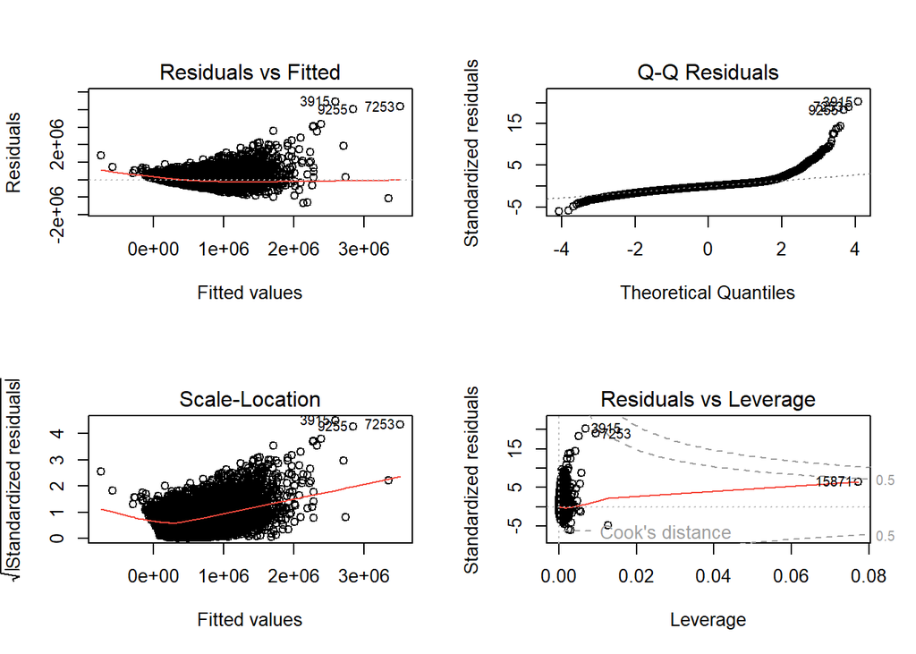

```r
par(mfrow = c(2, 2))
plot(model)
```

On the Residuals vs Fitted plot, homoscedasticity of ordinary least squares estimation is clearly violated. Variance in residuals increases as fitted values increase. We can additionally support the violation of homoscedasticity by looking at the crookedness of Scale-Location plot. Q-Q plot of residuals is violated too. There are strong lower and upper tails. On the Residuals vs Leverage plot, even though there are points that are close to boundaries, most of them are within the range. So we can say that there are not many influential or outlier cases in linear regression analysis.

2-) Produce a histogram and a QQ-plot of the response variable price, as well as of its log transform log(price). Compare both distributions to the normal one. Fit now a linear model with the response variable log(price). Compare the estimated model with the one from (a) in terms of R2, significance and effect of covariates and model fit (via residual analysis). Which model is more adequate?

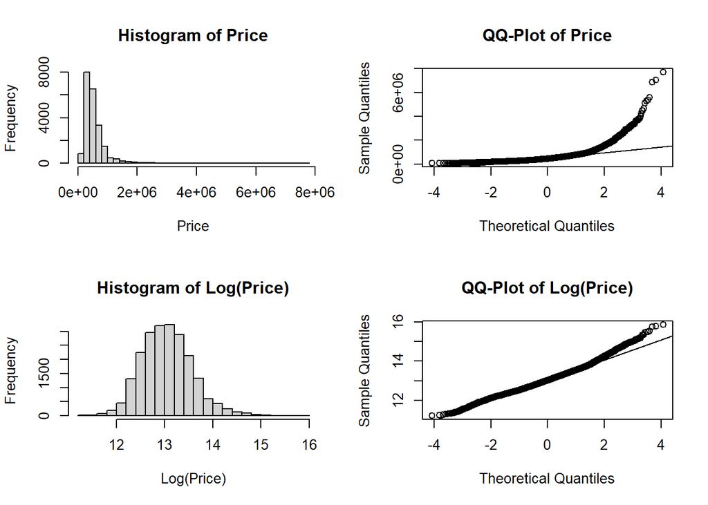

```r
kc_house_data$log_price <- log(kc_house_data$price)

par(mfrow = c(2, 2))
# Histogram of price
hist(kc_house_data$price, main = "Histogram of Price", xlab = "Price", breaks = 30)

# QQ-plot of price
qqnorm(kc_house_data$price, main = "QQ-Plot of Price")
qqline(kc_house_data$price)

# Histogram of log(price)
hist(kc_house_data$log_price, main = "Histogram of Log(Price)", xlab = "Log(Price)", breaks = 30)

# QQ-plot of log(price)
qqnorm(kc_house_data$log_price, main = "QQ-Plot of Log(Price)")
qqline(kc_house_data$log_price)
```

Both the Histogram and QQ-Plot of price shows a very high right tail. Log(price) still has a slightly heavy tail but it is considerably very low.

```r
# Fit the linear model with log(price) as response
model_log_price <- lm(log_price ~ bedrooms + bathrooms + sqft_living + floors + view + condition + grade + yr_built, data = kc_house_data)

# Summary of the model
summary(model_log_price)
```

```
##
## Call:
## lm(formula = log_price ~ bedrooms + bathrooms + sqft_living +
##     floors + view + condition + grade + yr_built, data = kc_house_data)
##
## Residuals:
##      Min       1Q   Median       3Q      Max
## -1.90374 -0.21157  0.01624  0.21288  1.38880
##
## Coefficients:
##               Estimate Std. Error t value Pr(>|t|)
## (Intercept)  2.151e+01  1.884e-01 114.155  < 2e-16 ***
## bedrooms    -2.366e-02  2.937e-03  -8.056 8.28e-16 ***
## bathrooms    8.500e-02  4.956e-03  17.152  < 2e-16 ***
## sqft_living  1.664e-04  4.701e-06  35.402  < 2e-16 ***
## floors       8.569e-02  4.968e-03  17.246  < 2e-16 ***
## view         6.740e-02  2.994e-03  22.510  < 2e-16 ***
## condition    4.226e-02  3.580e-03  11.803  < 2e-16 ***
## grade        2.218e-01  3.108e-03  71.359  < 2e-16 ***
## yr_built    -5.526e-03  9.699e-05 -56.980  < 2e-16 ***
## ---
## Signif. codes:  0 '***' 0.001 '**' 0.01 '*' 0.05 '.' 0.1 ' ' 1
##
## Residual standard error: 0.3149 on 21604 degrees of freedom
## Multiple R-squared:  0.6426, Adjusted R-squared:  0.6425
## F-statistic:  4856 on 8 and 21604 DF,  p-value: < 2.2e-16
```

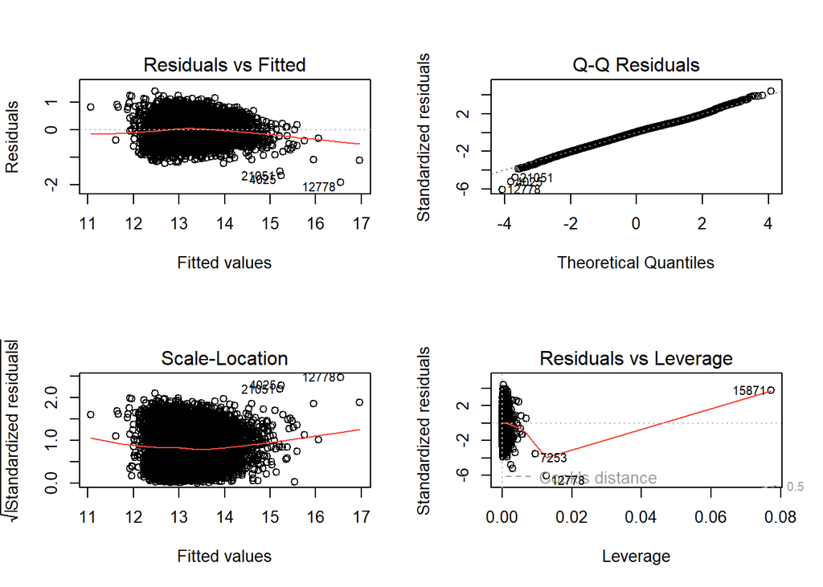

```r
par(mfrow = c(2, 2))
plot(model_log_price)
```

Residuals vs Fitted and Scale-Location plots shows that homoscedasticity problem is highly resolved. Q-Q Plot also follows a straight line. And we cannot even see the most of dashed lines in Residuals vs Leverage. The point 12778 seems pretty close to the one below tho.

In summary, the model with log(price) as the response variable appears to be more appropriate as it:

- Has a higher R-squared value, indicating a better fit.
- Shows stronger relationships between predictors and the response variable.
- Demonstrates improved residual distribution, suggesting fewer outliers and a more consistent error structure.

3-) In the model from (b) interpret the effect of each covariate on the response. Plot each covariate against log(price). Is the assumption of the linear dependence between covariates and response plausible for all covariates? Add to the model from (b) squared terms for yr_built and sqft_living. Are these terms significant? Does adding these two terms improve the model fit in terms of R2?

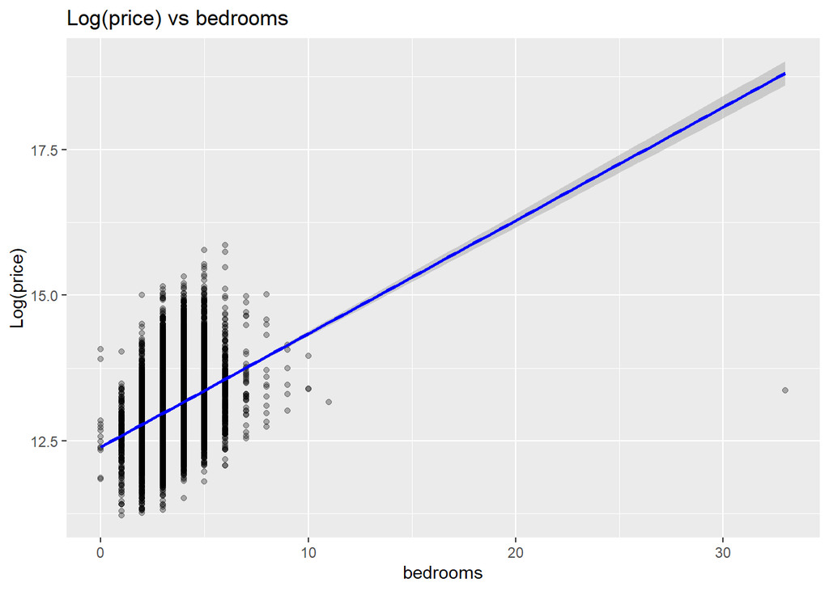

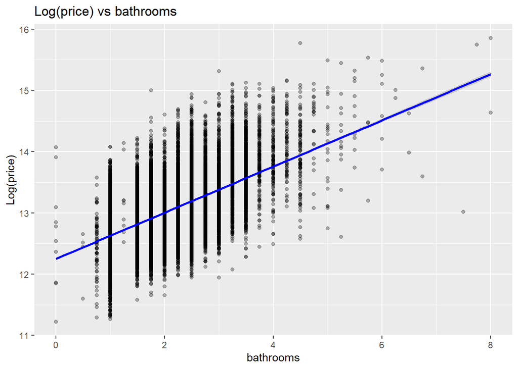

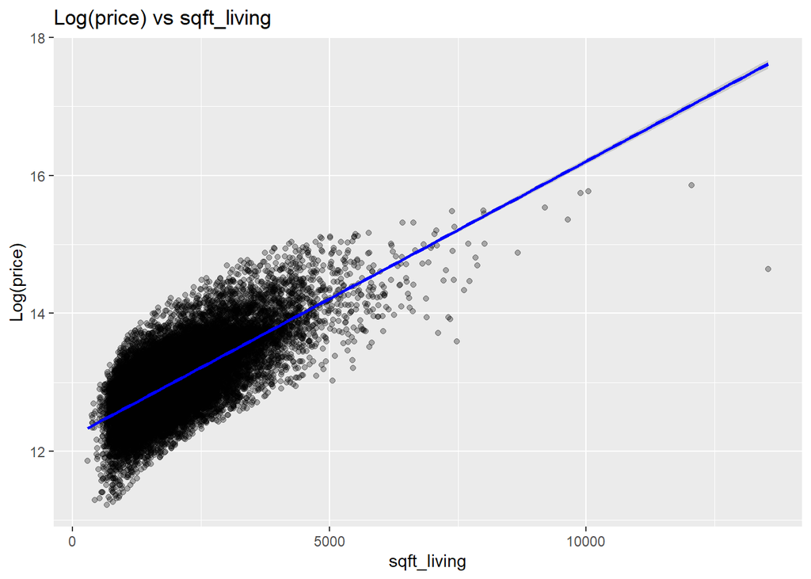

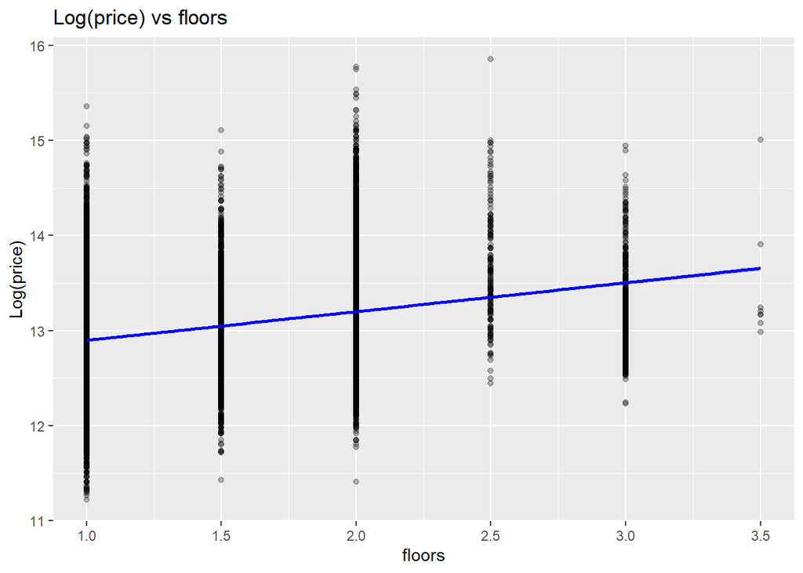

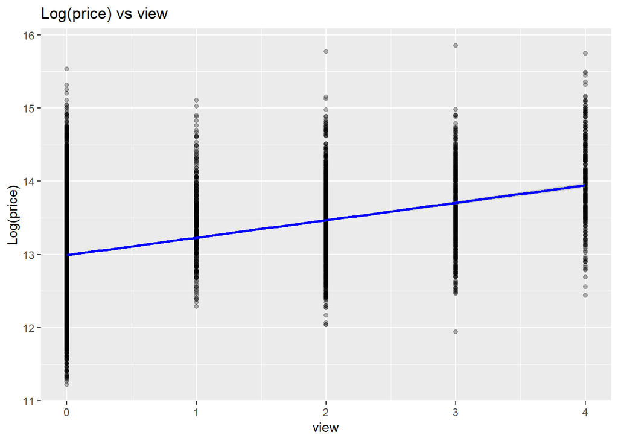

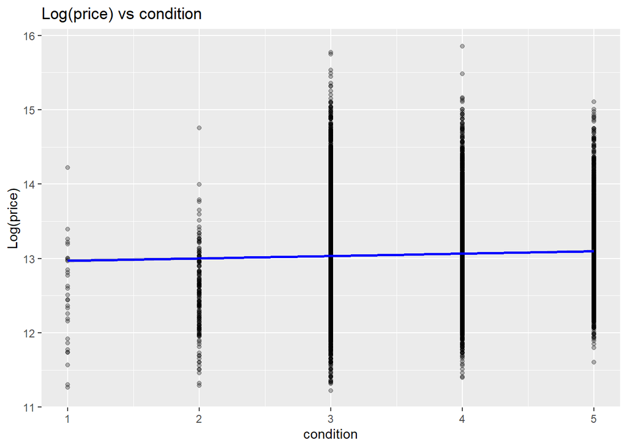

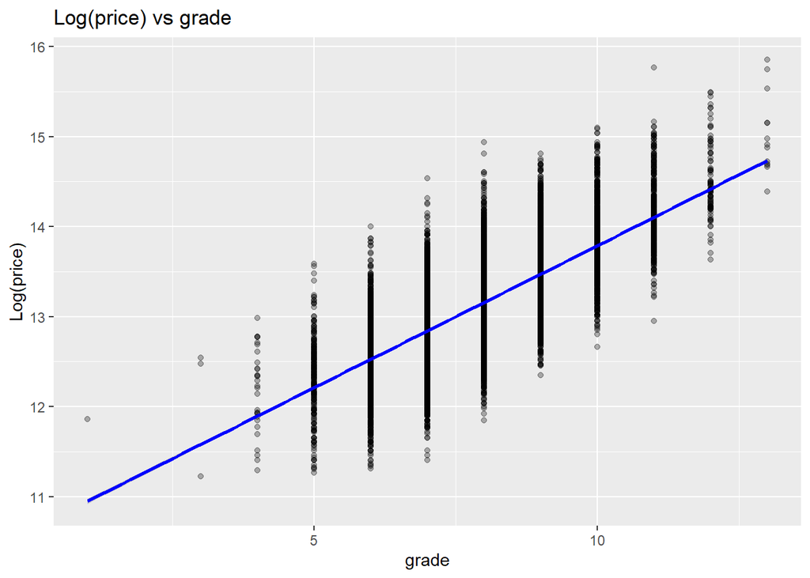

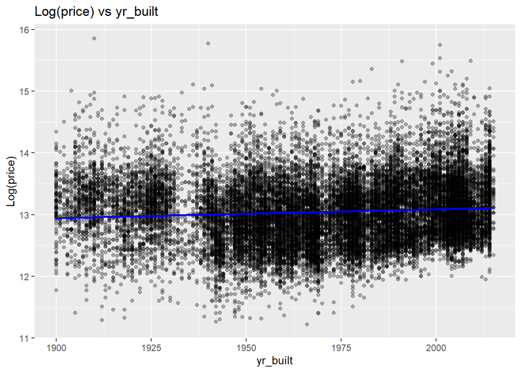

```r
covariates <- c("bedrooms", "bathrooms", "sqft_living", "floors", "view", "condition", "grade", "yr_built")

# Create plots
for (var in covariates) {
  p <- ggplot(kc_house_data, aes_string(x = var, y = "log_price")) +
    geom_point(alpha = 0.3) +
    geom_smooth(method = "lm", col = "blue") +
    labs(title = paste("Log(price) vs", var), x = var, y = "Log(price)")
  print(p)
}
```

Variables bathrooms and grade can likely have a linear relationship. But the rest of variables seem to either have a different relationship such as sqft_living or they don’t explain any variance in the predictor variables such as yr_built.

```r
# Fit the new model with squared terms
model_log_price_sq <- lm(log_price ~ bedrooms + bathrooms + sqft_living + floors + view + condition + grade + yr_built + I(yr_built^2) + I(sqft_living^2), data = kc_house_data)

summary(model_log_price_sq)
```

```
##
## Call:
## lm(formula = log_price ~ bedrooms + bathrooms + sqft_living +
##     floors + view + condition + grade + yr_built + I(yr_built^2) +
##     I(sqft_living^2), data = kc_house_data)
##
## Residuals:
##     Min      1Q  Median      3Q     Max
## -1.2644 -0.2113  0.0138  0.2107  1.4160
##
## Coefficients:
##                    Estimate Std. Error t value Pr(>|t|)
## (Intercept)       1.674e+02  1.082e+01  15.470   <2e-16 ***
## bedrooms         -2.978e-02  3.009e-03  -9.895   <2e-16 ***
## bathrooms         7.317e-02  4.959e-03  14.754   <2e-16 ***
## sqft_living       2.792e-04  8.690e-06  32.132   <2e-16 ***
## floors            4.733e-02  5.613e-03   8.432   <2e-16 ***
## view              7.222e-02  2.979e-03  24.247   <2e-16 ***
## condition         4.640e-02  3.591e-03  12.920   <2e-16 ***
## grade             2.176e-01  3.092e-03  70.355   <2e-16 ***
## yr_built         -1.545e-01  1.106e-02 -13.978   <2e-16 ***
## I(yr_built^2)     3.802e-05  2.823e-06  13.468   <2e-16 ***
## I(sqft_living^2) -1.782e-08  1.172e-09 -15.212   <2e-16 ***
## ---
## Signif. codes:  0 '***' 0.001 '**' 0.01 '*' 0.05 '.' 0.1 ' ' 1
##
## Residual standard error: 0.312 on 21602 degrees of freedom
## Multiple R-squared:  0.6492, Adjusted R-squared:  0.649
## F-statistic:  3998 on 10 and 21602 DF,  p-value: < 2.2e-16
```

The terms are significant. And the R2 value is slightly improved from 0.6426 to 0.6492. Adjusted R-Squared is increased as well.

4-) Now we would like to compare how well models from (b) and (c) make prediction. For this divide the dataset into a training and a test set. Sample randomly 10 806 rows to include into the training set and the rest will be the test set. To ensure comparability of the results set.seed(1122) before sampling. Fit both models on the training set and make prediction on the test set. Calculate the mean squared difference between predicted values and values of log(price) from the test set for each model. Which prediction error is smaller? Try to extend the model to improve the prediction: my best model gives prediction error of 0.09557445.

```r
set.seed(1122)
training_indices <- sample(seq_len(nrow(kc_house_data)), size = 10806)
training_set <- kc_house_data[training_indices, ]
test_set <- kc_house_data[-training_indices, ]

model_log_price_train <- lm(log_price ~ bedrooms + bathrooms + sqft_living + floors + view + condition + grade + yr_built, data = training_set)

model_log_price_sq_train <- lm(log_price ~ bedrooms + bathrooms + sqft_living + floors + view + condition + grade + yr_built + I(yr_built^2) + I(sqft_living^2), data = training_set)

pred_log_price <- predict(model_log_price_train, newdata = test_set)

pred_log_price_sq <- predict(model_log_price_sq_train, newdata = test_set)

mse_log_price <- mean((test_set$log_price - pred_log_price)^2)
mse_log_price
```

```
## [1] 0.09773623
```

```r
mse_log_price_sq <- mean((test_set$log_price - pred_log_price_sq)^2)
mse_log_price_sq
```

```
## [1] 0.09654389
```

```r
summary(model_log_price_sq_train)
```

```
##
## Call:
## lm(formula = log_price ~ bedrooms + bathrooms + sqft_living +
##     floors + view + condition + grade + yr_built + I(yr_built^2) +
##     I(sqft_living^2), data = training_set)
##
## Residuals:
##      Min       1Q   Median       3Q      Max
## -1.27870 -0.21116  0.01557  0.21234  1.24413
##
## Coefficients:
##                    Estimate Std. Error t value Pr(>|t|)
## (Intercept)       1.682e+02  1.542e+01  10.905  < 2e-16 ***
## bedrooms         -3.577e-02  4.441e-03  -8.054 8.87e-16 ***
## bathrooms         8.322e-02  7.122e-03  11.685  < 2e-16 ***
## sqft_living       2.946e-04  1.182e-05  24.915  < 2e-16 ***
## floors            4.793e-02  8.094e-03   5.922 3.27e-09 ***
## view              7.555e-02  4.215e-03  17.925  < 2e-16 ***
## condition         4.778e-02  5.060e-03   9.442  < 2e-16 ***
## grade             2.151e-01  4.388e-03  49.009  < 2e-16 ***
## yr_built         -1.551e-01  1.575e-02  -9.846  < 2e-16 ***
## I(yr_built^2)     3.812e-05  4.023e-06   9.476  < 2e-16 ***
## I(sqft_living^2) -2.032e-08  1.530e-09 -13.281  < 2e-16 ***
## ---
## Signif. codes:  0 '***' 0.001 '**' 0.01 '*' 0.05 '.' 0.1 ' ' 1
##
## Residual standard error: 0.3136 on 10795 degrees of freedom
## Multiple R-squared:  0.6483, Adjusted R-squared:  0.648
## F-statistic:  1990 on 10 and 10795 DF,  p-value: < 2.2e-16
```

```r
# Extention

model_log_price_new <- lm(log_price ~ bedrooms +  bedrooms : bathrooms  +  bathrooms : grade + sqft_living +sqft_living:floors + grade + floors  + condition + yr_built + I(yr_built^2) + I(sqft_living^2) +view + view:bathrooms  + I(floors^2) +I(grade^2), data = training_set)

pred_log_price_new <- predict(model_log_price_new, newdata = test_set)

mse_log_price_new <- mean((test_set$log_price - pred_log_price_new)^2)

print(paste0("Prediction error: ", mse_log_price_new))
```

```
## [1] "Prediction error: 0.0955503269486845"
```

```r
summary(model_log_price_new)
```

```
##
## Call:
## lm(formula = log_price ~ bedrooms + bedrooms:bathrooms + bathrooms:grade +
##     sqft_living + sqft_living:floors + grade + floors + condition +
##     yr_built + I(yr_built^2) + I(sqft_living^2) + view + view:bathrooms +
##     I(floors^2) + I(grade^2), data = training_set)
##
## Residuals:
##      Min       1Q   Median       3Q      Max
## -1.33179 -0.21106  0.01422  0.20827  1.24543
##
## Coefficients:
##                      Estimate Std. Error t value Pr(>|t|)
## (Intercept)         1.805e+02  1.555e+01  11.610  < 2e-16 ***
## bedrooms           -5.006e-02  9.538e-03  -5.249 1.56e-07 ***
## sqft_living         3.331e-04  1.516e-05  21.971  < 2e-16 ***
## grade               3.484e-01  2.637e-02  13.209  < 2e-16 ***
## floors             -1.560e-01  4.186e-02  -3.725 0.000196 ***
## condition           4.560e-02  5.054e-03   9.023  < 2e-16 ***
## yr_built           -1.679e-01  1.588e-02 -10.572  < 2e-16 ***
## I(yr_built^2)       4.134e-05  4.054e-06  10.197  < 2e-16 ***
## I(sqft_living^2)   -1.712e-08  2.088e-09  -8.198 2.73e-16 ***
## view                1.036e-01  1.233e-02   8.401  < 2e-16 ***
## I(floors^2)         7.512e-02  1.062e-02   7.073 1.61e-12 ***
## I(grade^2)         -9.345e-03  1.681e-03  -5.558 2.80e-08 ***
## bedrooms:bathrooms  6.053e-03  3.804e-03   1.591 0.111555
## bathrooms:grade     7.375e-03  2.007e-03   3.675 0.000239 ***
## sqft_living:floors -2.407e-05  7.730e-06  -3.113 0.001854 **
## bathrooms:view     -1.205e-02  4.605e-03  -2.617 0.008889 **
## ---
## Signif. codes:  0 '***' 0.001 '**' 0.01 '*' 0.05 '.' 0.1 ' ' 1
##
## Residual standard error: 0.3123 on 10790 degrees of freedom
## Multiple R-squared:  0.6514, Adjusted R-squared:  0.6509
## F-statistic:  1344 on 15 and 10790 DF,  p-value: < 2.2e-16
```

Although the model model_log_price_new or pred_log_price_sq performs slightly better, it usually does not mean the model generalizes better. I particularly had to try many different interaction effects or polynomial fits on this split. With different splits, different interactions or effects can give different results.

## Penalized Regression

#### Dataset

Consider the dataset hitters.dat on baseball players that has been analysed in the book An introduction to statistical learning by G. James, D. Witten, T. Hastie and R. Tibshirani (2013, Springer). It contains the following 20 variables:

- AtBat: Number of times at bat in 1986
- Hits: Number of hits in 1986
- HmRun: Number of home runs in 1986
- Runs: Number of runs in 1986
- RBI: Number of runs batted in 1986
- Walks: Number of walks in 1986
- Years: Number of years in the major leagues
- CAtBat: Number of times at bat during his career
- CHits: Number of hits during his career
- CHmRun: Number of home runs during his career
- CRuns: Number of runs during his career
- CRBI: Number of runs batted in during his career
- CWalks: Number of walks during his career
- League: A factor with levels A and N indicating player’s league at the end of 1986
- Division: A factor with levels E and W indicating player’s division at the end of 1986
- PutOuts: Number of put outs in 1986
- Assists: Number of assists in 1986
- Errors: Number of errors in 1986
- Salary: 1987 annual salary on opening day in thousands of dollars
- NewLeague: A factor with levels A and N indicating player’s league at the beginning of 1987

We would like to explain Salary of a player using the other variables. The function glmnet in the package glmnet is used to fit both ridge and lasso regression. Supply α = 0 for ridge and α = 1 for lasso when calling glmnet. Make sure you understand the interpretation of λ in both cases (note that it is not the same for lasso and ridge!). Read the documentation ?glmnet to understand what is the exact form of the objective function that is being minimised.

1-) Load the dataset into R and create a new dataset containing only those players for which all data is available.

```r
Hitters <- Hitters[complete.cases(Hitters),]
```

2-) Find the condition number (ratio between largest and smallest eigenvalue) of $X^T X$, where y is the salary and X represents all the other variables. What can you say about the condition number? Does it help if you standardise the design matrix, such that its columns (without the intercept) have mean zero and variance one?

```r
x = model.matrix(Salary~., Hitters)[,-1]
condition.number <- function (x){
  z <- t(x) %*% x
  print(max(svd(z)$d)/min(svd(z)$d))
  print(kappa(z, exact = T))
  }

condition.number(x)
```

```
## [1] 424299885
## [1] 424299885
```

```r
condition.number(scale(x))
```

```
## [1] 6131.339
## [1] 6131.339
```

$$\begin{align}
\frac{\|\Delta \boldsymbol{x}\| / \|\boldsymbol{x}\|}{\|\Delta
\boldsymbol{b}\| / \|\boldsymbol{b}\|} &= \frac{\|\Delta
\boldsymbol{x}\| \|\boldsymbol{b}\|}{\|\boldsymbol{x}\| \|\Delta
\boldsymbol{b}\|}\\
&= \frac{\|{\bf A}^{-1} \Delta \boldsymbol{b}\| \|{\bf A}
\boldsymbol{x}\|}{\|\boldsymbol{x}\| \|\Delta \boldsymbol{b}\|}\\
&\le \frac{\|{\bf A}^{-1}\| \|\Delta \boldsymbol{b}\| \|{\bf A}\|
\|\boldsymbol{x}\|}{\|\boldsymbol{x}\| \|\Delta \boldsymbol{b}\|} \\
&= \|{\bf A}^{-1}\| \|{\bf A}\|\\ &= \text{cond}({\bf A})
\end{align}$$

where we used $\|{\bf A}\boldsymbol{x}\| \le \|{\bf A}\| \|\boldsymbol{x}\|, \forall \boldsymbol{x}$. Then
$$\frac{\|\Delta \boldsymbol{x}\|}{\|\boldsymbol{x}\|} \le
\text{cond}({\bf A})\frac{\|\Delta
\boldsymbol{b}\|}{\|\boldsymbol{b}\|} \qquad (1)$$

Therefore, if we know the relative error in input, then we can use the condition number of the system to obtain an upper bound for the relative error of our computed solution (output). For more information, check out the [link](https://courses.engr.illinois.edu/cs357/sp2024/notes/ref-10-condition.html).

When the matrix is standardized, condition number decreases drastically. In this [answer](https://stats.stackexchange.com/questions/243000/cause-of-a-high-condition-number-in-a-python-statsmodels-regression#comment462188_243000) the reason for a high condition number is clearly explained. This is because they’re fitting a line to the points and then projecting the line all the way back to the origin (x=0) to find the y-intercept. That y-intercept will be very sensitive to small movements in the data points. The condition number takes into account high sensitivity in either fitted parameter to the input data, hence the high condition number when all of the data are far to one side of x=0.

3-) Fit a standard linear model (no regularisation) and a ridge regression with λ = 70. Compare the size of the coefficients in the two models. What do you observe?

```r
y = Hitters %>%
  select(Salary) %>%
  unlist() %>%
  as.numeric()

# Fit a standard linear model
lm_model <- lm(Salary ~ ., data = Hitters)

# Get the coefficients of the linear model
lm_coefficients <- coef(lm_model)
print("Linear Model Coefficients:")
```

```
## [1] "Linear Model Coefficients:"
```

```r
print(lm_coefficients)
```

```
##  (Intercept)        AtBat         Hits        HmRun         Runs          RBI
##  163.1035878   -1.9798729    7.5007675    4.3308829   -2.3762100   -1.0449620
##        Walks        Years       CAtBat        CHits       CHmRun        CRuns
##    6.2312863   -3.4890543   -0.1713405    0.1339910   -0.1728611    1.4543049
##         CRBI       CWalks      LeagueN    DivisionW      PutOuts      Assists
##    0.8077088   -0.8115709   62.5994230 -116.8492456    0.2818925    0.3710692
##       Errors   NewLeagueN
##   -3.3607605  -24.7623251
```

```r
# Fit a ridge regression model with lambda = 70
ridge_model <- glmnet(x, y, alpha = 0, lambda = 70)

# Get the coefficients of the ridge regression model
ridge_coefficients <- coef(ridge_model)
print("Ridge Regression Coefficients with lambda = 70:")
```

```
## [1] "Ridge Regression Coefficients with lambda = 70:"
```

```r
print(ridge_coefficients)
```

```
## 20 x 1 sparse Matrix of class "dgCMatrix"
##                        s0
## (Intercept)  3.364118e+01
## AtBat       -2.242666e-01
## Hits         1.644728e+00
## HmRun       -1.057644e+00
## Runs         1.173291e+00
## RBI          8.334793e-01
## Walks        2.435300e+00
## Years       -4.566521e+00
## CAtBat       8.250831e-03
## CHits        9.457427e-02
## CHmRun       5.887674e-01
## CRuns        1.879741e-01
## CRBI         1.939934e-01
## CWalks      -9.289755e-02
## LeagueN      4.151885e+01
## DivisionW   -1.142969e+02
## PutOuts      2.404133e-01
## Assists      9.828542e-02
## Errors      -2.986010e+00
## NewLeagueN  -4.722875e+00
```

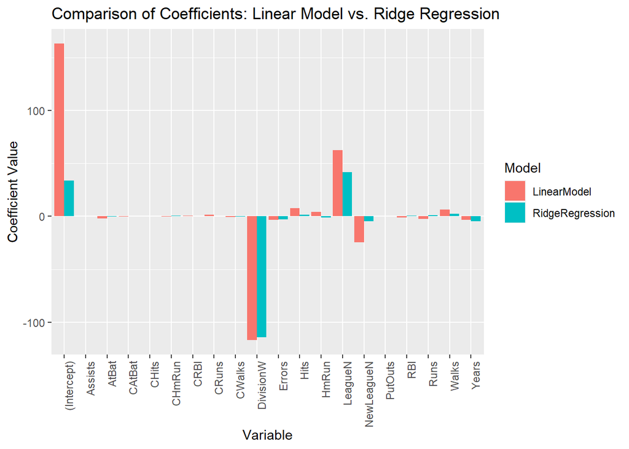

```r
# Standard Linear Model Coefficients
lm_coefficients <- coef(lm_model)
lm_coefficients <- as.data.frame(lm_coefficients)
colnames(lm_coefficients) <- "LinearModel"

# Ridge Regression Coefficients with lambda = 70
ridge_coefficients <- coef(ridge_model)
ridge_coefficients <- as.data.frame(as.matrix(ridge_coefficients))
colnames(ridge_coefficients) <- "RidgeRegression"

# Combine the data frames, making sure row names are kept as a column
comparison_df <- data.frame(
  Variable = rownames(lm_coefficients),
  LinearModel = lm_coefficients$LinearModel,
  RidgeRegression = ridge_coefficients$RidgeRegression
)

comparison_df_tidy <- pivot_longer(
  comparison_df,
  cols = c("LinearModel", "RidgeRegression"),
  names_to = "Model",
  values_to = "Coefficient"
)


ggplot(comparison_df_tidy, aes(x = Variable, y = Coefficient, fill = Model)) +
  geom_bar(stat = "identity", position = "dodge") +
  theme(axis.text.x = element_text(angle = 90, hjust = 1)) +
  labs(title = "Comparison of Coefficients: Linear Model vs. Ridge Regression",
       x = "Variable",
       y = "Coefficient Value")
```

glm() by default standardizes the data. The importance of standardization in regularized models are thoroughly examined in the exercise before. Here in Ridge Regression, the coefficients are generally smaller, indicating that the regularization term λ is effectively shrinking them. This often results in a model that generalizes better to new data by mitigating multicollinearity and reducing overfitting.

4-) The value 70 for λ is arbitrary and we would like to find a data-driven way to choose it. The criterion to compare is the mean squared prediction error as in exercise 4 (d) on linear regression. Split the data randomly into a training and a test set with set.seed(1122).

```r
set.seed(1122)

train = Hitters %>%
  sample_frac(0.8)

test = Hitters %>%
  setdiff(train)

x_train = model.matrix(Salary~., train)[,-1]
x_test = model.matrix(Salary~., test)[,-1]

y_train = train %>%
  select(Salary) %>%
  unlist() %>%
  as.numeric()

y_test = test %>%
  select(Salary) %>%
  unlist() %>%
  as.numeric()

cv.out = cv.glmnet(x_train, y_train, alpha = 0) # Fit ridge regression model on training data
bestlam = cv.out$lambda.min  # Select lamda that minimizes training MSE
bestlam
```

```
## [1] 195.0848
```

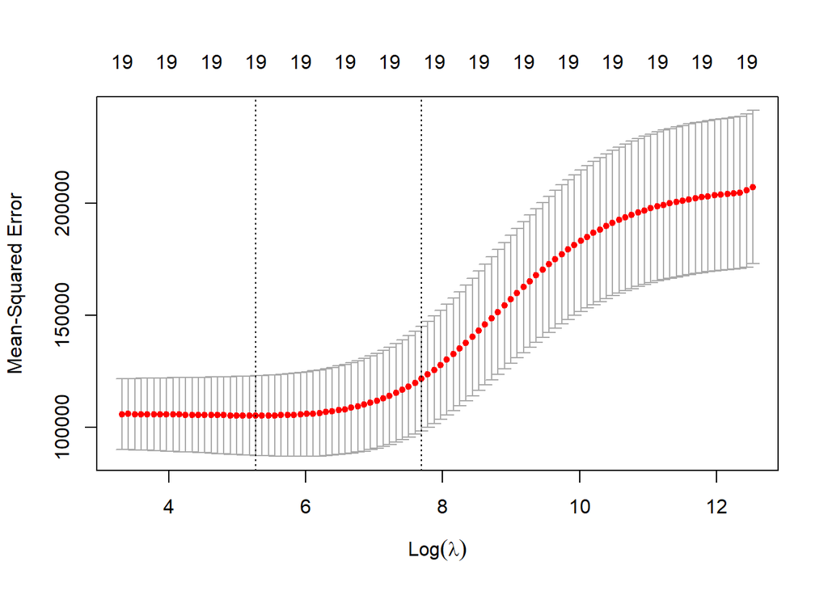

```r
plot(cv.out)
```

```r
# What is the test MSE associated with this value of  λ?
ridge_model.best.l <- glmnet(x_train, y_train, alpha=0, lambda = bestlam)
ridge_pred = predict(ridge_model.best.l, s = bestlam, newx = x_test) # Use best lambda to predict test data
mean((ridge_pred - y_test)^2)
```

```
## [1] 170198
```

I think the best way to perform this task would be to use the built-in cross-validation function, cv.glmnet(). By default, the function performs 10-fold cross-validation.

5-) Write a function that takes λ as argument, fits a ridge regression on the training sets and calculates the mean squared prediction error on the test set. Run this function on a logarithmic grid (e.g., 10^seq(from = 10, to = -2, length = 100)). Plot the results against log(λ) and graphically find the value λopt that minimises the mean squared prediction error.

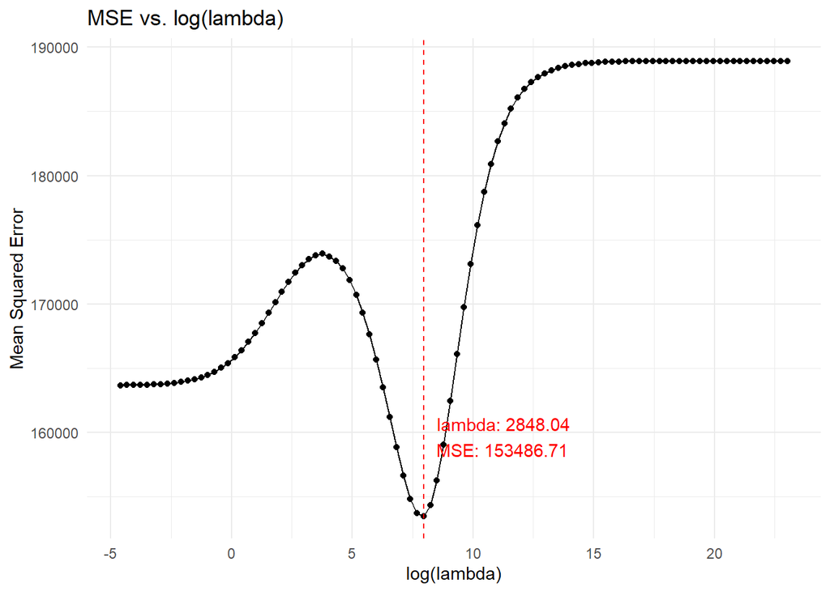

```r
ridge_mse <- function(lambda, x_train, y_train, x_test, y_test) {
  ridge_mod <- glmnet(x_train, y_train, alpha = 0, lambda = lambda)
  y_pred <- predict(ridge_mod, s = lambda, newx = x_test)
  mse <- mean((y_test - y_pred)^2)
  return(mse)
}

# Grid of lambda values
lambda_grid <- 10^seq(10, -2, length = 100)

# Calculate MSE for each lambda
mse_values <- sapply(lambda_grid, ridge_mse, x_train = x_train, y_train = y_train, x_test = x_test, y_test = y_test)

# Find the optimal lambda that minimizes MSE
optimal_lambda <- lambda_grid[which.min(mse_values)]
optimal_mse <- min(mse_values)

# Plot the results
plot_data <- data.frame(
  log_lambda = log(lambda_grid),
  mse = mse_values
)

ggplot(plot_data, aes(x = log_lambda, y = mse)) +
  geom_line() +
  geom_point() +
  geom_vline(xintercept = log(optimal_lambda), linetype = "dashed", color = "red") +
  annotate("text", x = log(optimal_lambda), y = optimal_mse, label = paste0("lambda: ", round(optimal_lambda, 2), "\nMSE: ", round(optimal_mse, 2)), hjust = -0.1, vjust = -1.5, color = "red") +
  labs(title = "MSE vs. log(lambda)",
       x = "log(lambda)",
       y = "Mean Squared Error") +
  theme_minimal()
```

```r
# Print the optimal lambda value
cat("The optimal lambda value is:", optimal_lambda, "\n")
```

```
## The optimal lambda value is: 2848.036
```

6-) Fit a ridge regression with λopt on all the data, and interpret some of the coefficients. Which are the most important variables? Are there coefficients that equal zero exactly?

```r
# Fit a ridge regression with optimal lambda on all the data
ridge_model_optimal <- glmnet(x, y, alpha = 0, lambda = optimal_lambda)
optimal_ridge_coefficients <- as.vector(coef(ridge_model_optimal))
names(optimal_ridge_coefficients) <- rownames(coef(ridge_model_optimal))

print("Ridge Regression Coefficients with optimal lambda:")
```

```
## [1] "Ridge Regression Coefficients with optimal lambda:"
```

```r
important_variables <- sort(abs(optimal_ridge_coefficients), decreasing = TRUE)
important_variables
```

```
##  (Intercept)    DivisionW      LeagueN   NewLeagueN        Years        HmRun
## 2.223901e+02 2.082440e+01 2.983368e+00 2.754473e+00 2.422382e+00 1.155873e+00
##        Walks         Runs          RBI         Hits       CHmRun       Errors
## 7.471647e-01 5.780387e-01 5.780215e-01 3.587712e-01 2.111369e-01 1.333063e-01
##        AtBat         CRBI       CWalks        CRuns      PutOuts        CHits
## 8.772007e-02 5.892103e-02 5.727541e-02 5.697871e-02 5.037146e-02 2.841393e-02
##       CAtBat      Assists
## 7.394802e-03 7.194273e-03
```

Intercept and DivisionW are pretty important in ridge regression. There are not any coefficients that are set to 0.

7-) Repeat parts (d), (e) and (f) for lasso instead of ridge. Are there now coefficients that are equal to zero?

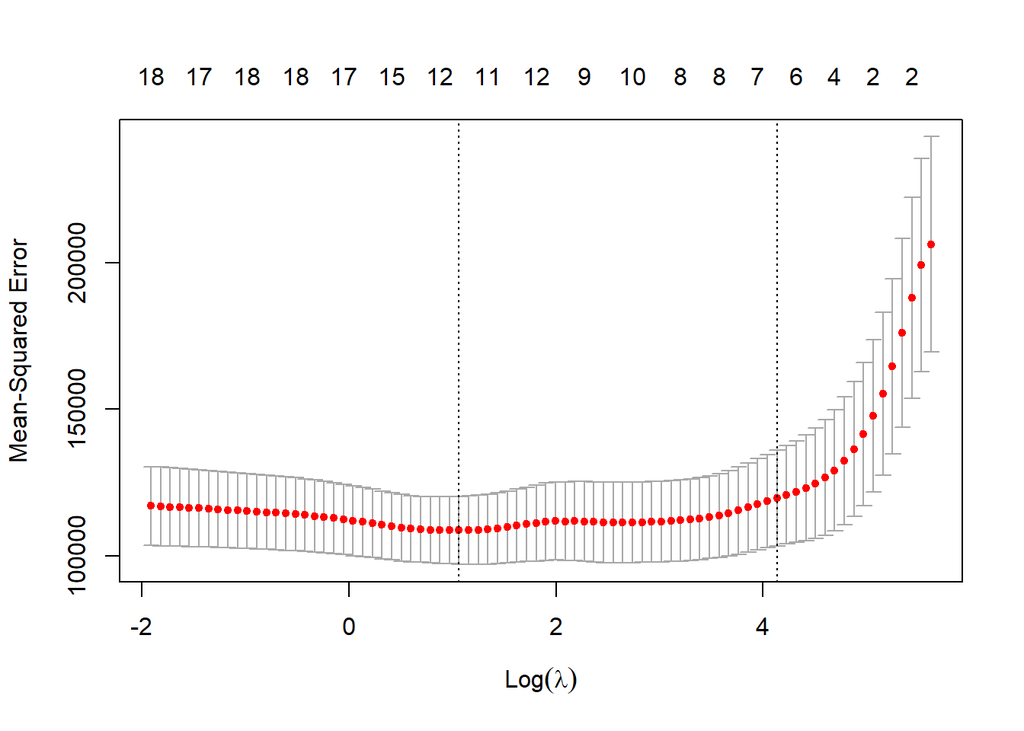

```r
# Fit lasso regression model with cross-validation
cv.out_lasso <- cv.glmnet(x_train, y_train, alpha = 1)
bestlam_lasso <- cv.out_lasso$lambda.min

# Plot cross-validation results
plot(cv.out_lasso)
```

```r
# Calculate the test MSE associated with the best lambda for lasso
lasso_model_best <- glmnet(x_train, y_train, alpha = 1, lambda = bestlam_lasso)
lasso_pred <- predict(lasso_model_best, s = bestlam_lasso, newx = x_test)
test_mse_lasso <- mean((lasso_pred - y_test)^2)
cat("The test MSE associated with the best CV lambda for lasso is:", test_mse_lasso, "\n")
```

```
## The test MSE associated with the best CV lambda for lasso is: 170943.5
```

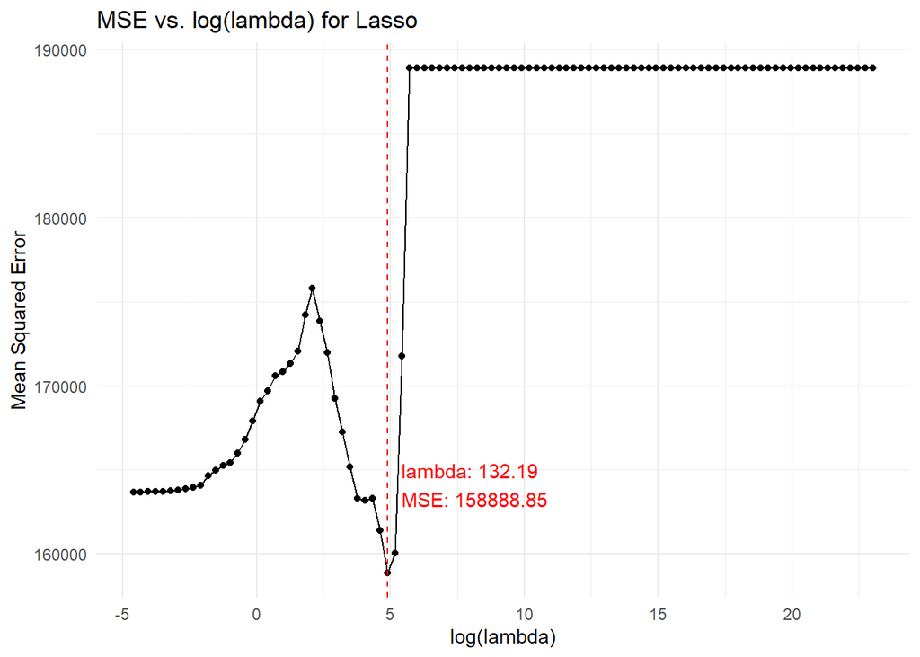

```r
# Define the function to calculate MSE
lasso_mse <- function(lambda, x_train, y_train, x_test, y_test) {
  lasso_mod <- glmnet(x_train, y_train, alpha = 1, lambda = lambda)
  y_pred <- predict(lasso_mod, s = lambda, newx = x_test)
  mse <- mean((y_test - y_pred)^2)
  return(mse)
}

# Grid of lambda values
lambda_grid_lasso <- 10^seq(10, -2, length = 100)

# Calculate MSE for each lambda
mse_values_lasso <- sapply(lambda_grid_lasso, lasso_mse, x_train = x_train, y_train = y_train, x_test = x_test, y_test = y_test)

# Find the optimal lambda that minimizes MSE
optimal_lambda_lasso <- lambda_grid_lasso[which.min(mse_values_lasso)]
optimal_mse_lasso <- min(mse_values_lasso)

# Plot the results
plot_data_lasso <- data.frame(
  log_lambda = log(lambda_grid_lasso),
  mse = mse_values_lasso
)

ggplot(plot_data_lasso, aes(x = log_lambda, y = mse)) +
  geom_line() +
  geom_point() +
  geom_vline(xintercept = log(optimal_lambda_lasso), linetype = "dashed", color = "red") +
  annotate("text", x = log(optimal_lambda_lasso), y = optimal_mse_lasso, label = paste0("lambda: ", round(optimal_lambda_lasso, 2), "\nMSE: ", round(optimal_mse_lasso, 2)), hjust = -0.1, vjust = -1.5, color = "red") +
  labs(title = "MSE vs. log(lambda) for Lasso",
       x = "log(lambda)",
       y = "Mean Squared Error") +
  theme_minimal()
```

```r
cat("The optimal lambda value for lasso is:", optimal_lambda_lasso, "\n")
```

```
## The optimal lambda value for lasso is: 132.1941
```

```r
# Fit a lasso regression with optimal lambda on all the data
lasso_model_optimal <- glmnet(x, y, alpha = 1, lambda = optimal_lambda_lasso)
optimal_lasso_coefficients <- as.vector(coef(lasso_model_optimal))
names(optimal_lasso_coefficients) <- rownames(coef(lasso_model_optimal))

important_lasso_variables <- sort(abs(optimal_lasso_coefficients), decreasing = TRUE)
important_lasso_variables
```

```
##  (Intercept)         Hits        Walks         CRBI        CRuns        AtBat
## 316.02183375   0.72112214   0.56907852   0.25371287   0.09666601   0.00000000
##        HmRun         Runs          RBI        Years       CAtBat        CHits
##   0.00000000   0.00000000   0.00000000   0.00000000   0.00000000   0.00000000
##       CHmRun       CWalks      LeagueN    DivisionW      PutOuts      Assists
##   0.00000000   0.00000000   0.00000000   0.00000000   0.00000000   0.00000000
##       Errors   NewLeagueN
##   0.00000000   0.00000000
```

The difference between ridge and lasso regression is that Lasso tends to make coefficients to absolute zero as compared to Ridge which never sets the value of coefficient to absolute zero. Therefore, Lasso puts more weights on individual coefficients. Intercept, Hits, Walks, CRBI and CRuns are all non zero in Lasso regression.

## Logistic regression

#### Dataset

Go to UCI Machine learning repository and download the data on blood donation. This page contains also the background information on the data. The goal is to build a model that allows to predict best if a donor will donate blood. The dataset contains the following variables:

- recency: months since last donation
- frequency: total number of donations
- amount: total blood donated in c.c.
- time: months since first donation
- donation: 1 stands for donating blood, 0 stands for not donating blood

#### Exercises

1-) Read the data into R and fit a generalised linear model with the binary response donation and covariate frequency using the canonical link function. Fit the same model replacing the covariate by amount. Compare it to the first model. Plot the variable frequency against amount. Comment on the results. Do you need both of these variables in the model?

```r
# Read the data into R
transfusion <- read.csv("transfusion.data", col.names = c("recency", "frequency", "amount", "time", "donation"))

# Fit a GLM with donation as the response and frequency as the predictor
model_frequency <- glm(donation ~ frequency, data = transfusion, family = binomial(link = "logit"))

# Summary of the model
summary(model_frequency)
```

```
##
## Call:
## glm(formula = donation ~ frequency, family = binomial(link = "logit"),
##     data = transfusion)
##
## Coefficients:
##             Estimate Std. Error z value Pr(>|z|)
## (Intercept) -1.63796    0.12822 -12.774  < 2e-16 ***
## frequency    0.07937    0.01514   5.243 1.58e-07 ***
## ---
## Signif. codes:  0 '***' 0.001 '**' 0.01 '*' 0.05 '.' 0.1 ' ' 1
##
## (Dispersion parameter for binomial family taken to be 1)
##
##     Null deviance: 820.89  on 747  degrees of freedom
## Residual deviance: 789.12  on 746  degrees of freedom
## AIC: 793.12
##
## Number of Fisher Scoring iterations: 4
```

```r
# Fit a GLM with donation as the response and amount as the predictor
model_amount <- glm(donation ~ amount, data = transfusion, family = binomial(link = "logit"))

# Summary of the model
summary(model_amount)
```

```
##
## Call:
## glm(formula = donation ~ amount, family = binomial(link = "logit"),
##     data = transfusion)
##
## Coefficients:
##               Estimate Std. Error z value Pr(>|z|)
## (Intercept) -1.638e+00  1.282e-01 -12.774  < 2e-16 ***
## amount       3.175e-04  6.056e-05   5.243 1.58e-07 ***
## ---
## Signif. codes:  0 '***' 0.001 '**' 0.01 '*' 0.05 '.' 0.1 ' ' 1
##
## (Dispersion parameter for binomial family taken to be 1)
##
##     Null deviance: 820.89  on 747  degrees of freedom
## Residual deviance: 789.12  on 746  degrees of freedom
## AIC: 793.12
##
## Number of Fisher Scoring iterations: 4
```

```r
# Compare the two models using AIC
aic_frequency <- AIC(model_frequency)
aic_amount <- AIC(model_amount)

cat("AIC for model with frequency as predictor:", aic_frequency, "\n")
```

```
## AIC for model with frequency as predictor: 793.1162
```

```r
cat("AIC for model with amount as predictor:", aic_amount, "\n")
```

```
## AIC for model with amount as predictor: 793.1162
```

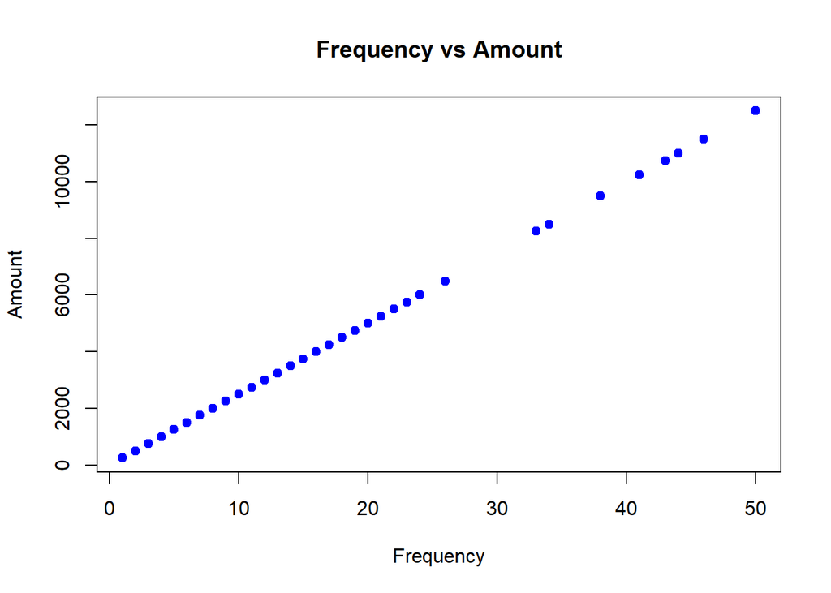

```r
# Plot frequency against amount
plot(transfusion$frequency, transfusion$amount,
     xlab = "Frequency",
     ylab = "Amount",
     main = "Frequency vs Amount",
     pch = 19,
     col = "blue")
```

```r
# Check correlation between frequency and amount
correlation <- cor(transfusion$frequency, transfusion$amount)
cat("Correlation between frequency and amount:", correlation, "\n")
```

```
## Correlation between frequency and amount: 1
```

The correlation of 1 between frequency and amount indicates perfect collinearity, meaning that these two variables provide the same information. In this case, including both variables in the model is redundant, and it would be appropriate to use only one of them.

Since the AIC values for the models with frequency and amount as predictors are the same, it confirms that both predictors contribute equally to the model. Given this perfect collinearity, we only need one of these variables in our model.

2-) Fit now the GLM model with the response donation and covariate recency using all link functions available in the glm function. Compare obtained estimators and comment on the differences.

```r
fit_logit <- glm(donation ~ recency, data = transfusion, family = binomial(link = "logit"))
fit_probit <- glm(donation ~ recency, data = transfusion, family = binomial(link = "probit"))
fit_cauchit <- glm(donation ~ recency, data = transfusion, family = binomial(link = "cauchit"))
fit_log <- glm(donation ~ recency, data = transfusion, family = binomial(link = "log"))
fit_cloglog <- glm(donation ~ recency, data = transfusion, family = binomial(link = "cloglog"))


summary(fit_logit)
```

```
##
## Call:
## glm(formula = donation ~ recency, family = binomial(link = "logit"),
##     data = transfusion)
##
## Coefficients:
##             Estimate Std. Error z value Pr(>|z|)
## (Intercept)  -0.2032     0.1363  -1.492    0.136
## recency      -0.1250     0.0165  -7.573 3.64e-14 ***
## ---
## Signif. codes:  0 '***' 0.001 '**' 0.01 '*' 0.05 '.' 0.1 ' ' 1
##
## (Dispersion parameter for binomial family taken to be 1)
##
##     Null deviance: 820.89  on 747  degrees of freedom
## Residual deviance: 743.55  on 746  degrees of freedom
## AIC: 747.55
##
## Number of Fisher Scoring iterations: 5
```

```r
summary(fit_probit)
```

```
##
## Call:
## glm(formula = donation ~ recency, family = binomial(link = "probit"),
##     data = transfusion)
##
## Coefficients:
##              Estimate Std. Error z value Pr(>|z|)
## (Intercept) -0.159627   0.081631  -1.955   0.0505 .
## recency     -0.069216   0.008766  -7.896 2.89e-15 ***
## ---
## Signif. codes:  0 '***' 0.001 '**' 0.01 '*' 0.05 '.' 0.1 ' ' 1
##
## (Dispersion parameter for binomial family taken to be 1)
##
##     Null deviance: 820.89  on 747  degrees of freedom
## Residual deviance: 744.33  on 746  degrees of freedom
## AIC: 748.33
##
## Number of Fisher Scoring iterations: 5
```

```r
summary(fit_cauchit)
```

```
##
## Call:
## glm(formula = donation ~ recency, family = binomial(link = "cauchit"),
##     data = transfusion)
##
## Coefficients:
##             Estimate Std. Error z value Pr(>|z|)
## (Intercept)  0.05060    0.14412   0.351    0.725
## recency     -0.17853    0.03265  -5.468 4.55e-08 ***
## ---
## Signif. codes:  0 '***' 0.001 '**' 0.01 '*' 0.05 '.' 0.1 ' ' 1
##
## (Dispersion parameter for binomial family taken to be 1)
##
##     Null deviance: 820.89  on 747  degrees of freedom
## Residual deviance: 745.50  on 746  degrees of freedom
## AIC: 749.5
##
## Number of Fisher Scoring iterations: 5
```

```r
summary(fit_log)
```

```
##
## Call:
## glm(formula = donation ~ recency, family = binomial(link = "log"),
##     data = transfusion)
##
## Coefficients:
##             Estimate Std. Error z value Pr(>|z|)
## (Intercept) -0.73594    0.08867  -8.300  < 2e-16 ***
## recency     -0.09726    0.01324  -7.343 2.08e-13 ***
## ---
## Signif. codes:  0 '***' 0.001 '**' 0.01 '*' 0.05 '.' 0.1 ' ' 1
##
## (Dispersion parameter for binomial family taken to be 1)
##
##     Null deviance: 820.89  on 747  degrees of freedom
## Residual deviance: 743.62  on 746  degrees of freedom
## AIC: 747.62
##
## Number of Fisher Scoring iterations: 6
```

```r
summary(fit_cloglog)
```

```
##
## Call:
## glm(formula = donation ~ recency, family = binomial(link = "cloglog"),
##     data = transfusion)
##
## Coefficients:
##             Estimate Std. Error z value Pr(>|z|)
## (Intercept) -0.47661    0.11101  -4.293 1.76e-05 ***
## recency     -0.11089    0.01482  -7.483 7.27e-14 ***
## ---
## Signif. codes:  0 '***' 0.001 '**' 0.01 '*' 0.05 '.' 0.1 ' ' 1
##
## (Dispersion parameter for binomial family taken to be 1)
##
##     Null deviance: 820.89  on 747  degrees of freedom
## Residual deviance: 743.47  on 746  degrees of freedom
## AIC: 747.47
##
## Number of Fisher Scoring iterations: 5
```

According to the documentation of ?glm(), “…the binomial family the links logit, probit, cauchit, (corresponding to logistic, normal and Cauchy CDFs respectively) log and cloglog (complementary log-log)”.

The comparison of GLM models using different link functions (logit, probit, cauchit, log, and cloglog) reveals distinct differences in their coefficient estimates and model fit. The logit and probit models, which are often similar, both show significant coefficients for recency, with the logit model having slightly larger coefficients. The cauchit model, based on the Cauchy distribution, exhibits more extreme coefficient values and a higher AIC, indicating a less favorable fit compared to logit and probit. The log model provides a different scale for the intercept and slightly smaller coefficients for recency, with an AIC comparable to the logit model.

The complementary log-log (cloglog) model shows the lowest AIC, suggesting the best fit among the models tested. Despite these variations, all models consistently indicate that recency is a significant predictor of donation.

3-) Now we would like to build a model that makes the best prediction for the blood donations. - First divide the dataset into a training and a test set. Sample randomly 374 rows to include into the training set and the rest will be the test set. To ensure comparability of the results set.seed(1122) before sampling. Fit a GLM model with the response donation and canonical link on the training set, choosing appropriate covariates. Predict the model on the test set.

```r
set.seed(1122)

# Randomly sample 374 rows for the training set
train_indices <- sample(1:nrow(transfusion), 374)
train_set <- transfusion[train_indices, ]
test_set <- transfusion[-train_indices, ]

# Fit a GLM model with the canonical link (logit) on the training set
glm_model <- glm(donation ~ recency + frequency + time, data = train_set, family = binomial(link = "logit"))

# Predict the model on the test set
test_set$predicted_prob <- predict(glm_model, newdata = test_set, type = "response")

# Print the summary of the fitted model
summary(glm_model)
```

```
##
## Call:
## glm(formula = donation ~ recency + frequency + time, family = binomial(link = "logit"),
##     data = train_set)
##
## Coefficients:
##              Estimate Std. Error z value Pr(>|z|)
## (Intercept) -0.351257   0.249155  -1.410 0.158600
## recency     -0.094233   0.024035  -3.921 8.83e-05 ***
## frequency    0.131617   0.037421   3.517 0.000436 ***
## time        -0.025462   0.008412  -3.027 0.002471 **
## ---
## Signif. codes:  0 '***' 0.001 '**' 0.01 '*' 0.05 '.' 0.1 ' ' 1
##
## (Dispersion parameter for binomial family taken to be 1)
##
##     Null deviance: 415.04  on 373  degrees of freedom
## Residual deviance: 356.99  on 370  degrees of freedom
## AIC: 364.99
##
## Number of Fisher Scoring iterations: 5
```

The canonical link function for the binomial distribution in generalized linear models (GLMs) is the *logit* function.

- With the predicted probability perform the classification: set the predicted ith value of donation to 0, if the corresponding ith predicted probability is less than 0.5 and to 1 otherwise. Assess the goodness of your classification calculating the mean absolute error. Try to extend the model to improve the classification error. Can you beat a performance of 0.2085561?

```r
train_set$log_amount <- log(train_set$amount + 1)
train_set$amount_t <- train_set$amount / train_set$time
train_set$r_a <- train_set$amount * train_set$recency

test_set$log_amount <- log(test_set$amount + 1)
test_set$amount_t <- test_set$amount / test_set$time
test_set$r_a <- test_set$amount * test_set$recency

glm_model_extended <- glm(donation ~ recency  + time + log_amount + r_a, data = train_set, family = binomial(link = "logit"))

summary(glm_model_extended)
```

```
##
## Call:
## glm(formula = donation ~ recency + time + log_amount + r_a, family = binomial(link = "logit"),
##     data = train_set)
##
## Coefficients:
##               Estimate Std. Error z value Pr(>|z|)
## (Intercept) -8.450e+00  1.842e+00  -4.587 4.50e-06 ***
## recency     -6.608e-02  3.557e-02  -1.857   0.0632 .
## time        -3.665e-02  9.163e-03  -4.000 6.33e-05 ***
## log_amount   1.334e+00  2.865e-01   4.656 3.22e-06 ***
## r_a         -1.964e-05  2.305e-05  -0.852   0.3942
## ---
## Signif. codes:  0 '***' 0.001 '**' 0.01 '*' 0.05 '.' 0.1 ' ' 1
##
## (Dispersion parameter for binomial family taken to be 1)
##
##     Null deviance: 415.04  on 373  degrees of freedom
## Residual deviance: 345.47  on 369  degrees of freedom
## AIC: 355.47
##
## Number of Fisher Scoring iterations: 5
```

```r
test_set$predicted_prob_extended <- predict(glm_model_extended, newdata = test_set, type = "response")


test_set$predicted_class <- ifelse(test_set$predicted_prob < 0.5, 0, 1)

test_set$predicted_class_extended <- ifelse(test_set$predicted_prob_extended < 0.5, 0, 1)

mean(abs(test_set$donation - test_set$predicted_class))
```

```
## [1] 0.2245989
```

```r
mean(abs(test_set$donation - test_set$predicted_class_extended))
```

```
## [1] 0.2032086
```

## Generalized linear models

#### Dataset

The dataset student-mat.csv can be found on Kaggle. This page contains a full description of the data and all the variables. Variables G1, G2, and G3 are first, second, and final grades in mathematics. The remaining variables are explanatory variables. We would like to identify variables that explain grades in mathematics.

1-) First we need to identify the distribution of each of G1, G2, and G3. Can each of these variables be assumed to follow a normal distribution? Justify your answer using suitable arguments and graphical tools. Can each of G1, G2, and G3 be assumed to follow a Poisson distribution? Are there signs for over-dispersion or any other anomalies in the distributions of any of G1, G2, or G3? Support your answer using suitable arguments and graphical tools.

```r
student.mat <- read.csv("student-mat.csv")

head(student.mat)
```

```
##   school sex age address famsize Pstatus Medu Fedu     Mjob     Fjob     reason
## 1     GP   F  18       U     GT3       A    4    4  at_home  teacher     course
## 2     GP   F  17       U     GT3       T    1    1  at_home    other     course
## 3     GP   F  15       U     LE3       T    1    1  at_home    other      other
## 4     GP   F  15       U     GT3       T    4    2   health services       home
## 5     GP   F  16       U     GT3       T    3    3    other    other       home
## 6     GP   M  16       U     LE3       T    4    3 services    other reputation
##   guardian traveltime studytime failures schoolsup famsup paid activities
## 1   mother          2         2        0       yes     no   no         no
## 2   father          1         2        0        no    yes   no         no
## 3   mother          1         2        3       yes     no  yes         no
## 4   mother          1         3        0        no    yes  yes        yes
## 5   father          1         2        0        no    yes  yes         no
## 6   mother          1         2        0        no    yes  yes        yes
##   nursery higher internet romantic famrel freetime goout Dalc Walc health
## 1     yes    yes       no       no      4        3     4    1    1      3
## 2      no    yes      yes       no      5        3     3    1    1      3
## 3     yes    yes      yes       no      4        3     2    2    3      3
## 4     yes    yes      yes      yes      3        2     2    1    1      5
## 5     yes    yes       no       no      4        3     2    1    2      5
## 6     yes    yes      yes       no      5        4     2    1    2      5
##   absences G1 G2 G3
## 1        6  5  6  6
## 2        4  5  5  6
## 3       10  7  8 10
## 4        2 15 14 15
## 5        4  6 10 10
## 6       10 15 15 15
```

```r
summary(student.mat[, c("G1", "G2", "G3")])
```

```
##        G1              G2              G3
##  Min.   : 3.00   Min.   : 0.00   Min.   : 0.00
##  1st Qu.: 8.00   1st Qu.: 9.00   1st Qu.: 8.00
##  Median :11.00   Median :11.00   Median :11.00
##  Mean   :10.91   Mean   :10.71   Mean   :10.42
##  3rd Qu.:13.00   3rd Qu.:13.00   3rd Qu.:14.00
##  Max.   :19.00   Max.   :19.00   Max.   :20.00
```

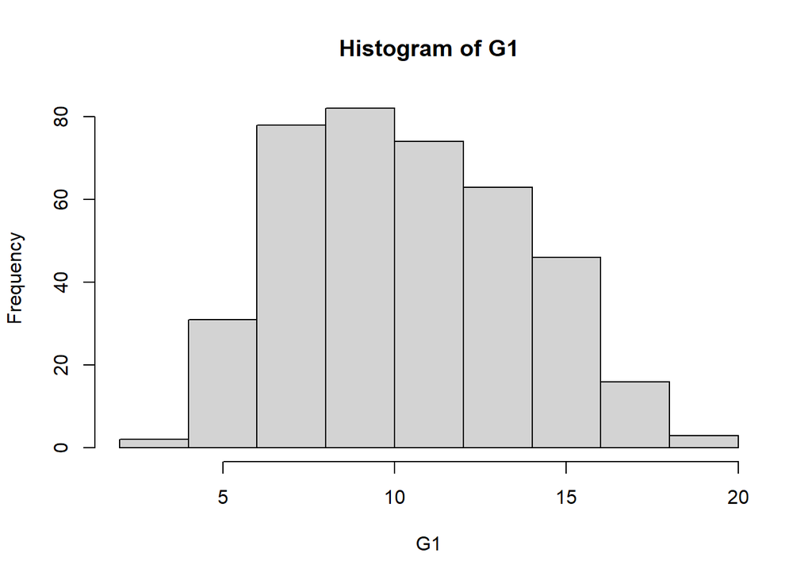

```r
# Normality Assessment
# Plot histograms
hist(student.mat$G1, breaks = 10, main = "Histogram of G1", xlab = "G1")
```

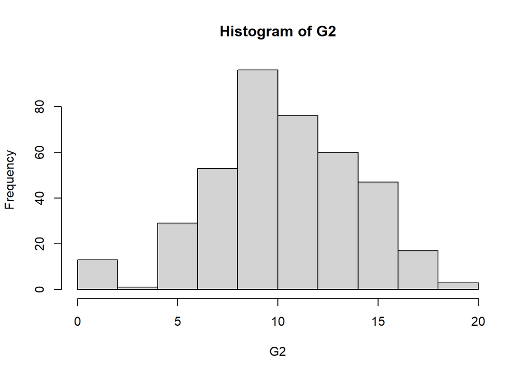

```r
hist(student.mat$G2, breaks = 10, main = "Histogram of G2", xlab = "G2")
```

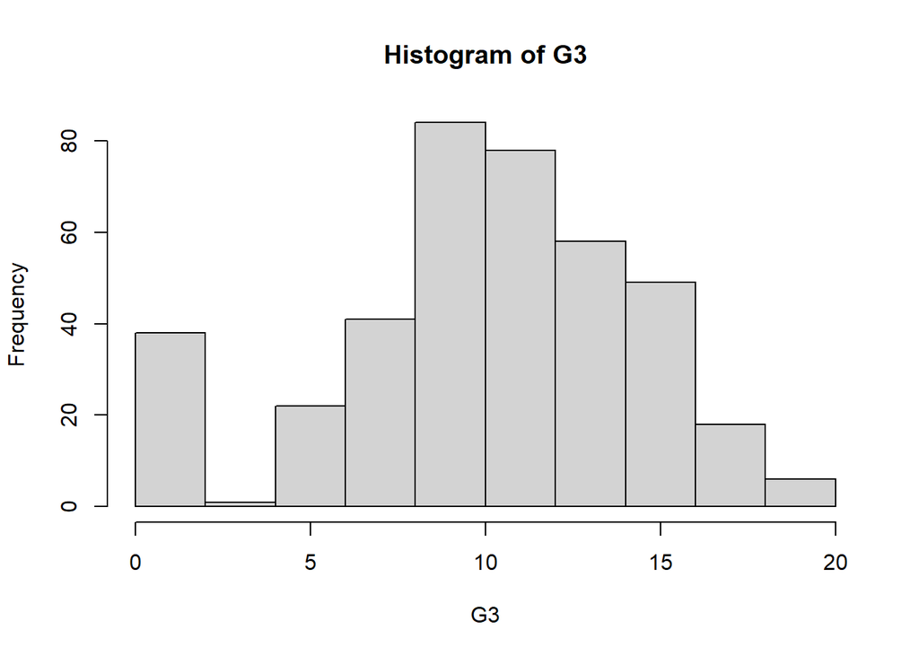

```r
hist(student.mat$G3, breaks = 10, main = "Histogram of G3", xlab = "G3")
```

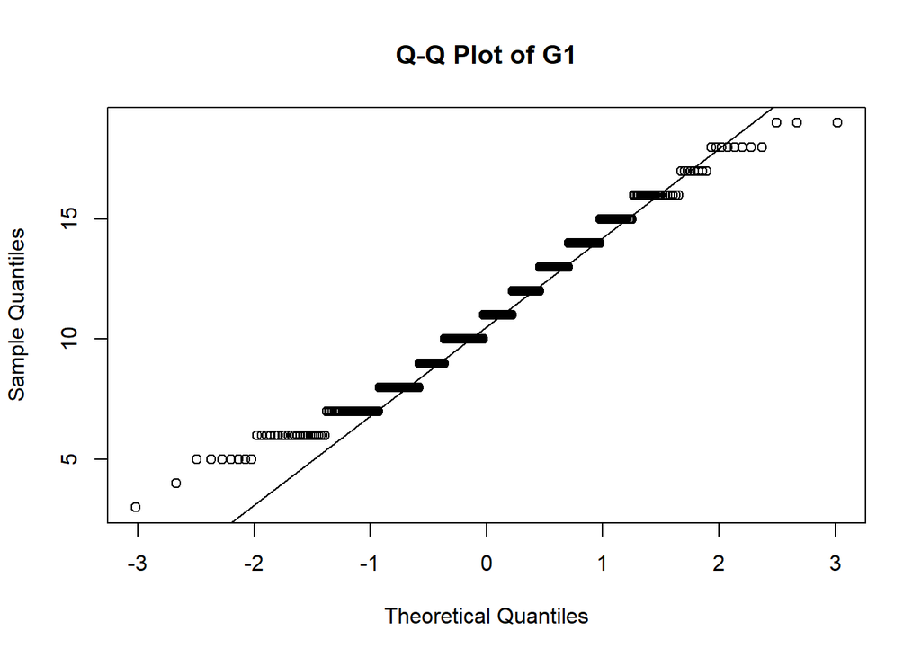

```r
# Plot Q-Q plots
qqnorm(student.mat$G1, main = "Q-Q Plot of G1")
qqline(student.mat$G1)
```

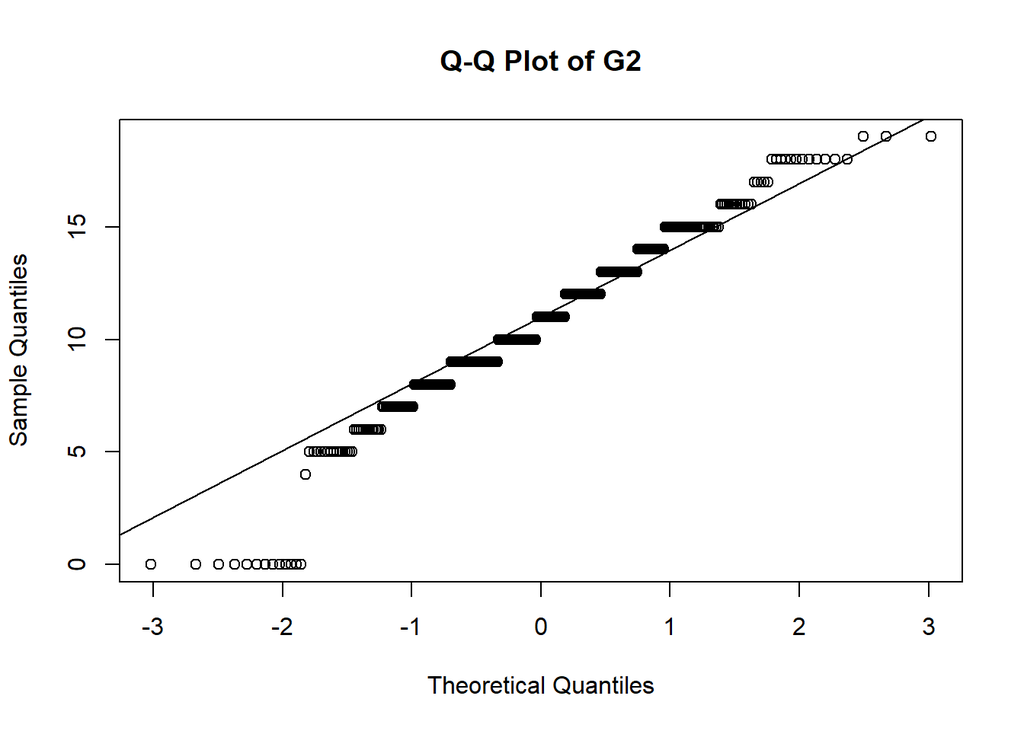

```r
qqnorm(student.mat$G2, main = "Q-Q Plot of G2")
qqline(student.mat$G2)
```

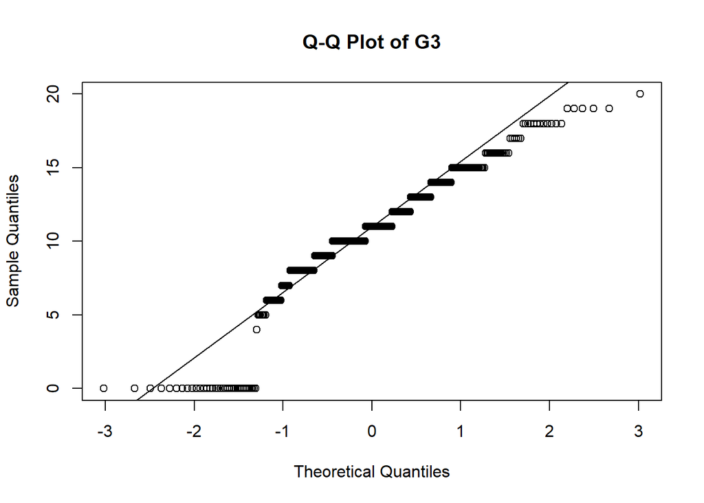

```r
qqnorm(student.mat$G3, main = "Q-Q Plot of G3")
qqline(student.mat$G3)
```

```
##
##  Chi-squared test for given probabilities
##
## data:  obs_freq
## X-squared = 24.785, df = 16, p-value = 0.0737
```

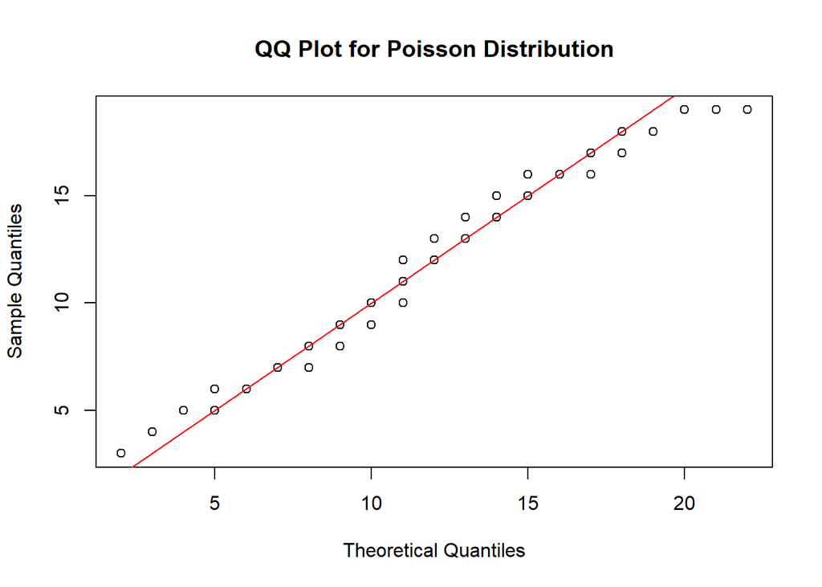

```
## G1 Poisson:
```

```r
dispersion.test.poisson <- function(data)
{
  obs_freq <- table(data)

  lambda <- mean(data)
  exp_freq <- dpois(as.numeric(names(obs_freq)), lambda) * length(data)

  chisq_test <- chisq.test(obs_freq, p = exp_freq, rescale.p = TRUE)
  print(chisq_test)

  qqplot(qpois(ppoints(length(data)), lambda), data,
         main = "QQ Plot for Poisson Distribution",
         xlab = "Theoretical Quantiles",
         ylab = "Sample Quantiles")
  abline(0, 1, col = "red")
}


cat("G1 Poisson: ", dispersion.test.poisson(student.mat$G1))
```

```r
cat("G2 Poisson: ", dispersion.test.poisson(student.mat$G2))
```

```
##
##  Chi-squared test for given probabilities
##
## data:  obs_freq
## X-squared = 19001, df = 16, p-value < 2.2e-16
```

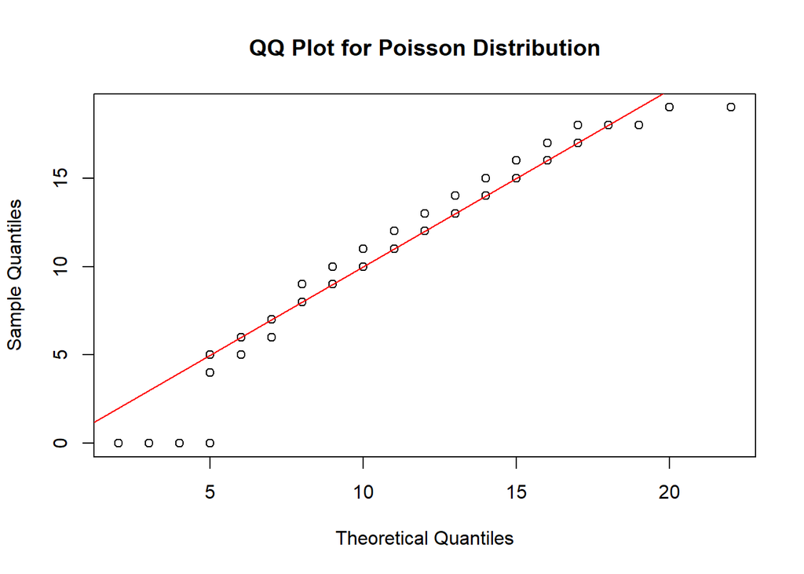

```
## G2 Poisson:
```

```r
cat("G3 Poisson: ", dispersion.test.poisson(student.mat$G3))
```

```
##
##  Chi-squared test for given probabilities
##
## data:  obs_freq
## X-squared = 120729, df = 17, p-value < 2.2e-16
```

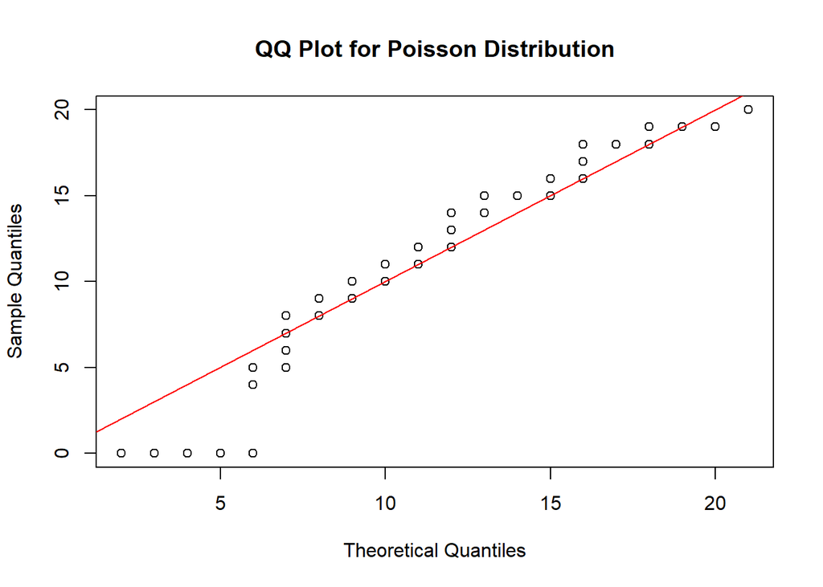

```
## G3 Poisson:
```

2-) Fit a suitable (generalised) linear model to explain G1 including all explanatory variables (Model 1). Are all covariates significant? Comment on the goodness-of-fit of this model. Calculate the Pearson residuals and Anscombe residuals and assess how closely they follow a normal distribution. Pursue the residual analysis and comment if the fitted (generalised) linear model is adequate for the data.

```r
model_G1 <- glm(G1 ~ .-G2-G3, data = student.mat, family = poisson)
summary(model_G1)
```

```
##
## Call:
## glm(formula = G1 ~ . - G2 - G3, family = poisson, data = student.mat)
##
## Coefficients:
##                   Estimate Std. Error z value Pr(>|z|)
## (Intercept)       2.418107   0.331755   7.289 3.13e-13 ***
## schoolMS          0.007157   0.058426   0.122  0.90250
## sexM              0.078237   0.036434   2.147  0.03176 *
## age              -0.006480   0.015983  -0.405  0.68515
## addressU          0.012823   0.043630   0.294  0.76882
## famsizeLE3        0.036639   0.035590   1.029  0.30325
## PstatusT          0.016047   0.053050   0.302  0.76227
## Medu              0.010664   0.023797   0.448  0.65405
## Fedu              0.014886   0.020349   0.732  0.46446
## Mjobhealth        0.078652   0.081444   0.966  0.33419
## Mjobother        -0.077025   0.054363  -1.417  0.15653
## Mjobservices      0.043696   0.059492   0.734  0.46266
## Mjobteacher      -0.083899   0.076545  -1.096  0.27305
## Fjobhealth       -0.042222   0.103856  -0.407  0.68434
## Fjobother        -0.100107   0.073860  -1.355  0.17530
## Fjobservices     -0.086835   0.076152  -1.140  0.25416
## Fjobteacher       0.096068   0.091322   1.052  0.29281
## reasonhome        0.015945   0.041353   0.386  0.69982
## reasonother      -0.017291   0.060594  -0.285  0.77537
## reasonreputation  0.038800   0.042441   0.914  0.36061
## guardianmother   -0.002677   0.039862  -0.067  0.94645
## guardianother     0.091135   0.074209   1.228  0.21942
## traveltime       -0.003407   0.025788  -0.132  0.89488
## studytime         0.053887   0.020846   2.585  0.00974 **
## failures         -0.147644   0.028151  -5.245 1.56e-07 ***
## schoolsupyes     -0.211886   0.052610  -4.027 5.64e-05 ***
## famsupyes        -0.093311   0.035213  -2.650  0.00805 **
## paidyes          -0.008676   0.035007  -0.248  0.80426
## activitiesyes    -0.007168   0.032921  -0.218  0.82763
## nurseryyes        0.004504   0.041064   0.110  0.91265
## higheryes         0.123398   0.087908   1.404  0.16041
## internetyes       0.019524   0.046777   0.417  0.67639
## romanticyes      -0.018513   0.034877  -0.531  0.59555
## famrel            0.001997   0.018196   0.110  0.91259
## freetime          0.023120   0.017435   1.326  0.18482
## goout            -0.037487   0.016743  -2.239  0.02516 *
## Dalc             -0.002047   0.025074  -0.082  0.93494
## Walc             -0.004639   0.018663  -0.249  0.80371
## health           -0.015492   0.011868  -1.305  0.19178
## absences          0.001520   0.002185   0.696  0.48662
## ---
## Signif. codes:  0 '***' 0.001 '**' 0.01 '*' 0.05 '.' 0.1 ' ' 1
##
## (Dispersion parameter for poisson family taken to be 1)
##
##     Null deviance: 402.47  on 394  degrees of freedom
## Residual deviance: 263.08  on 355  degrees of freedom
## AIC: 2000.2
##
## Number of Fisher Scoring iterations: 4
```

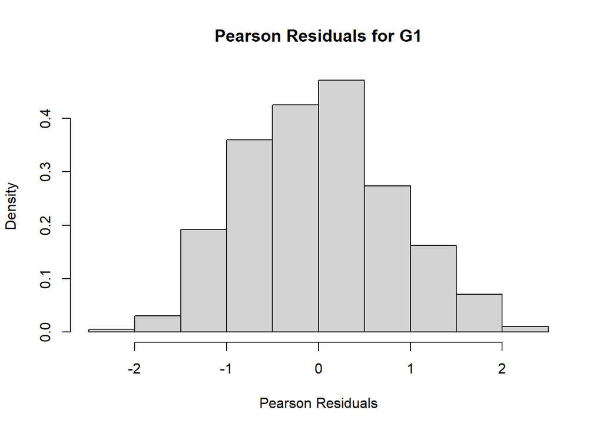

```r
predicted_G1 <- fitted(model_G1)

#  for Poisson regression var(predicted_G1) = predicted_G1
pearson_residuals_G1 <- (student.mat$G1 - predicted_G1) / sqrt(predicted_G1)

anscombe_residuals_G1 <- (3/2) * (student.mat$G1^(2/3) * predicted_G1^(-(1/6)) - predicted_G1^(1/2))

hist(pearson_residuals_G1, main = "Pearson Residuals for G1", xlab = "Pearson Residuals", probability = TRUE)
```

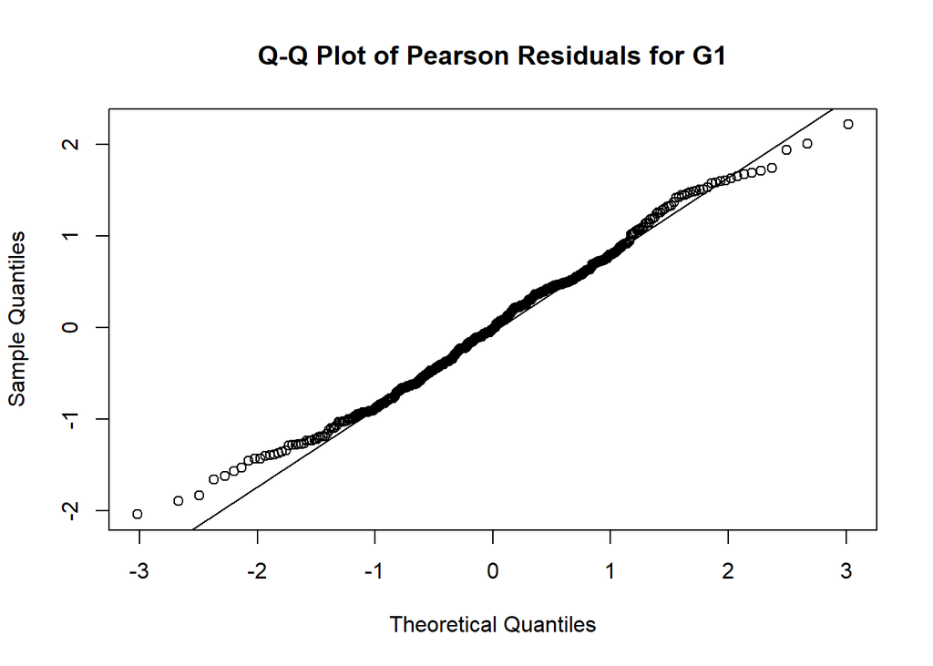

```r
qqnorm(pearson_residuals_G1, main = "Q-Q Plot of Pearson Residuals for G1")
qqline(pearson_residuals_G1)
```

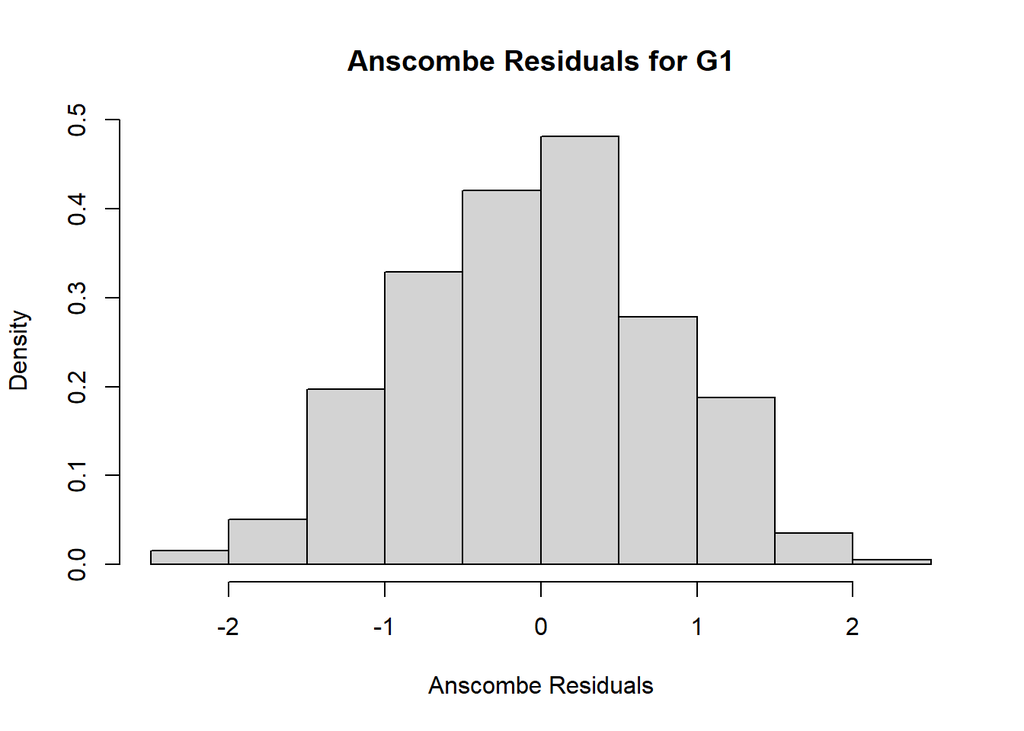

```r
hist(anscombe_residuals_G1, main = "Anscombe Residuals for G1", xlab = "Anscombe Residuals", probability = TRUE)
```

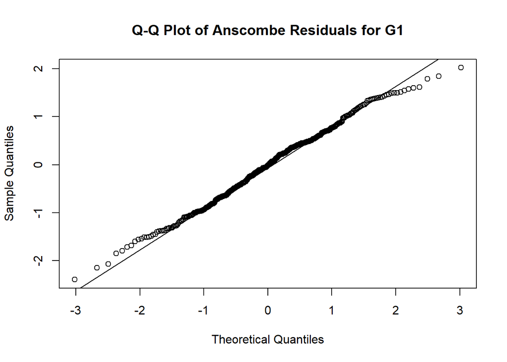

```r
qqnorm(anscombe_residuals_G1, main = "Q-Q Plot of Anscombe Residuals for G1")
qqline(anscombe_residuals_G1)
```

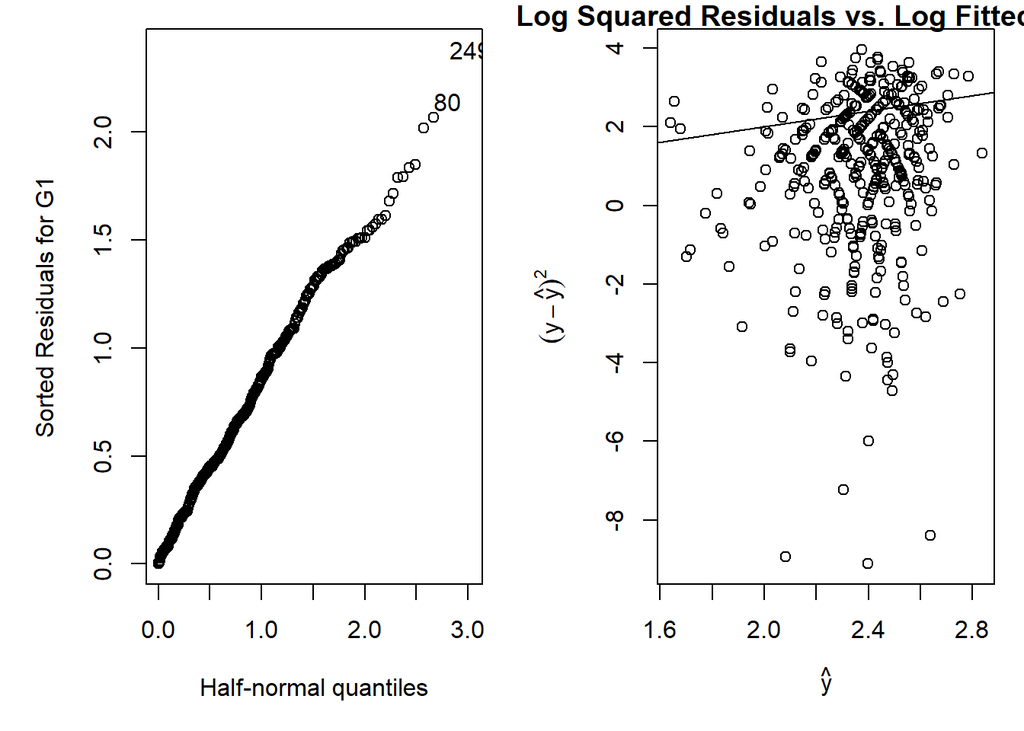

```r
# Calculate residuals and fitted values for G1
residuals_G1 <- residuals(model_G1)

# Half-normal plot and residuals vs. fitted values plot for G1
par(mfrow = c(1, 2), mar = c(5, 5, 1, 1))

# Half-normal plot of sorted residuals for G1
halfnorm(residuals_G1, ylab = "Sorted Residuals for G1")

# Residuals vs. fitted values plot (log scale) for G1
plot(log(predicted_G1), log((student.mat$G1 - predicted_G1)^2),
     xlab = expression(hat(y)), ylab = expression((y - hat(y))^2),
     main = "Log Squared Residuals vs. Log Fitted Values")
abline(0, 1)
```

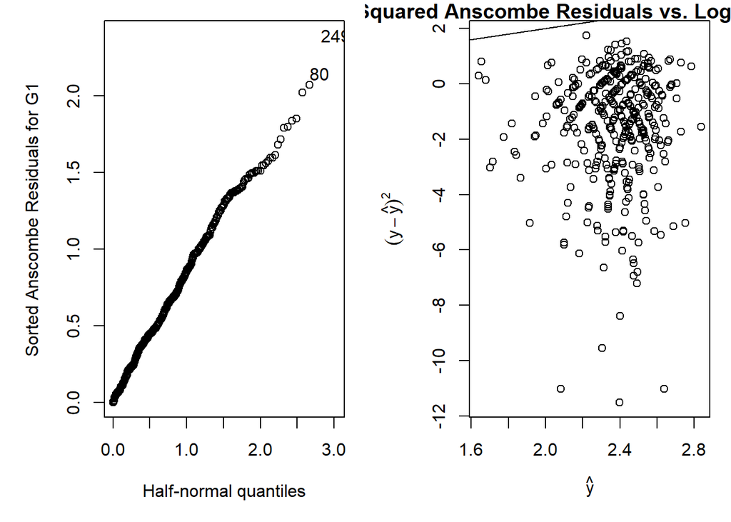

```r
# Residual analysis anscombe
par(mfrow = c(1, 2), mar = c(5, 5, 1, 1))

# Half-normal plot of sorted Anscombe residuals
halfnorm(anscombe_residuals_G1, ylab = "Sorted Anscombe Residuals for G1")

# Residuals vs. fitted values plot (log scale) for Anscombe residuals
plot(log(predicted_G1), log(anscombe_residuals_G1^2),
     xlab = expression(hat(y)), ylab = expression((y - hat(y))^2),
     main = "Log Squared Anscombe Residuals vs. Log Fitted Values")
abline(0, 1)
```

[figure not shown]

```r
# Anscombe residual analysis
halfnorm(anscombe_residuals_G1, ylab = "Sorted Anscombe Residuals for G1")

plot(log(predicted_G1), log(anscombe_residuals_G1^2),
     xlab = expression(hat(y)), ylab = expression((y - hat(y))^2),
     main = "Log Squared Anscombe Residuals vs. Log Fitted Values")
abline(0, 1)
```

```r
# Dispersion
sum(residuals(model_G1,type="pearson")^2)/model_G1$df.res
```

```
## [1] 0.7303499
```

Only the intercept, sexM, studytime, failures, schoolsupyes, famsupyes and goout seem to be significant. Dispersion can be considered as the goodness of fit of the model. As we expected, it is underdispersed with the dispersion value 0.7303499 < 1.

According to the book [2], “A disadvantage of the Pearson residual is that the distribution of pearson residual for non-Normal distributions is often markedly skewed, and so it may fail to have properties similar to those of a Normal-theory residual. Anscombe proposed defining a residual using a function A(y) in place of y, where A(.) is chosen to make the distribution of A(Y)”as Normal as possible’. When we look at both residuals, they do not follow a normal distribution. They are less dispersed than a normal distribution.

Residual analysis shows a very similar result. Most of the values are below the line and there are certainly some outliers.

3-) Take Model 1, but reduce the covariates to sex, Fedu, studytime, failures, schoolsup, famsup, goout (Model 2). Are all the covariates significant? Interpret the effect of each covariate on the grade. Assess the goodness-of-fit of this model. Perform analysis of deviance test to compare Model 1 and Model 2. Comment on the results. In Model 2 replace goout by Walc to get Model 3. How one can compare Model 2 and Model 3? Which model delivers a better fit? Justify your answer.

```r
compute_deviance <- function(model) {
  y <- model$y
  mu <- fitted(model)
  deviance <- 2 * sum(y * log(y / mu) - (y - mu))
  return(deviance)
}

model2_G1 <- glm(G1 ~ sex + Fedu + studytime + failures + schoolsup + famsup + goout,
                        data = student.mat, family = poisson)

summary(model2_G1)
```

```
##
## Call:
## glm(formula = G1 ~ sex + Fedu + studytime + failures + schoolsup +
##     famsup + goout, family = poisson, data = student.mat)
##
## Coefficients:
##              Estimate Std. Error z value Pr(>|z|)
## (Intercept)   2.34585    0.07578  30.955  < 2e-16 ***
## sexM          0.06585    0.03237   2.034  0.04193 *
## Fedu          0.04281    0.01482   2.888  0.00388 **
## studytime     0.05828    0.01906   3.057  0.00223 **
## failures     -0.13876    0.02495  -5.561 2.69e-08 ***
## schoolsupyes -0.19834    0.04978  -3.984 6.78e-05 ***
## famsupyes    -0.07330    0.03240  -2.263  0.02365 *
## goout        -0.03525    0.01406  -2.506  0.01220 *
## ---
## Signif. codes:  0 '***' 0.001 '**' 0.01 '*' 0.05 '.' 0.1 ' ' 1
##
## (Dispersion parameter for poisson family taken to be 1)
##
##     Null deviance: 402.47  on 394  degrees of freedom
## Residual deviance: 302.02  on 387  degrees of freedom
## AIC: 1975.1
##
## Number of Fisher Scoring iterations: 4
```

```r
deviance_full <- compute_deviance(model_G1)
deviance_m2 <- compute_deviance(model2_G1)

delta_D <- deviance_m2 - deviance_full

df <- length(coef(model_G1)) - length(coef(model2_G1))

# Critical value at 5% significance level
critical.value <- qchisq(0.95, df)

ifelse(delta_D > critical.value, "Reject reduced model, full model is better", "Fail to reject reduced model")
```

```
## [1] "Fail to reject reduced model"
```

```r
#Model 3
model3_G1 <- glm(G1 ~ sex + Fedu + studytime + failures + schoolsup + famsup + Walc,
                        data = student.mat, family = poisson)

deviance_m3 <- compute_deviance(model3_G1)

delta_D.2 <- deviance_m3 - deviance_m2
df.2 <- length(coef(model2_G1)) - length(coef(model3_G1))

critical.value.2 <- qchisq(0.95, df.2)

ifelse(delta_D.2 > critical.value.2, "Reject model 3, model 2 is better", "Fail to reject reduced model")
```

```
## [1] "Reject model 3, model 2 is better"
```

All covariates are significant at various levels, indicating they all contribute to the model2_G1 at the significance p < 0.05. A lower deviance and AIC compared to the null deviance (402.47) indicate a good fit of Model 2. In the first comparison, “Fail to reject reduced model” indicates Model 2 is not significantly worse than Model 1; thus, the reduced model is sufficient. In the second one “Reject model 3, model 2 is better” suggests replacing goout with Walc worsens the fit, and Model 2 is preferred.

## Mixed effects models and small area estimation

#### Dataset

Consider the survey and satellite data measuring the area for corn and soy fields in North-Central Iowa from 1978. Information is only available for few segments for the counties of interest. Detailed information was made available by passes of NASA’s LANDSAT satellites. The number of pixels for both crops is given up to segment level. The data set is available as landsat in the R-package JoSAE. We are interested in obtaining reliable estimates for the total size of corn and soy production for each of the 12 counties in the data set, respectively. Variables of interest:

- SegmentsInCounty: number of of segments of county.
- SegementID: identificator for segment.
- HACorn: hectares of corn for given segment.
- HASoybeans: hectares of soybeans for given segment.
- PixelsCorn: pixels for corn for given segment.
- PixelsSoybeans: pixels for soybeans for given segment.
- MeanPixelsCorn: mean of pixels for corn over all segments in given county.
- MeanPixelsSoybeans: mean of pixels for soybeans over all segments in given county.
- CountyName: county identificator of the segment.

```r
data(landsat)
landsat <- landsat[, c("SegmentsInCounty"
            ,"SegementID"
            ,"HACorn"
            ,"HASoybeans"
            ,"PixelsCorn"
            ,"PixelsSoybeans"
            ,"MeanPixelsCorn"
            ,"MeanPixelsSoybeans"
            ,"CountyName")]


head(landsat)
```

```
##   SegmentsInCounty SegementID HACorn HASoybeans PixelsCorn PixelsSoybeans
## 1              545          1 165.76       8.09        374             55
## 2              566          1  96.32     106.03        209            218
## 3              394          1  76.08     103.60        253            250
## 4              424          1 185.35       6.47        432             96
## 5              424          2 116.43      63.82        367            178
## 6              564          1 162.08      43.50        361            137
##   MeanPixelsCorn MeanPixelsSoybeans  CountyName
## 1         295.29             189.70 Cerro Gordo
## 2         300.40             196.65    Hamilton
## 3         289.60             205.28       Worth
## 4         290.74             220.22    Humboldt
## 5         290.74             220.22    Humboldt
## 6         318.21             188.06    Franklin
```

1-) Fit a suitable linear model to both the hectares of corn and soybeans for segment for each county. Explain your choice of included parameters. What are the limitations of the linear model? You might want to create a groupedData-object and use the nlme-function lmList.

```r
corn_data <- groupedData(HACorn ~ PixelsCorn | CountyName, data = landsat)
soy_data <- groupedData(HASoybeans ~ PixelsSoybeans | CountyName, data = landsat)

# Fit linear models for each county
lm_corn <- lmList(HACorn ~ PixelsCorn | CountyName, data = corn_data)
lm_soy <- lmList(HASoybeans ~ PixelsSoybeans | CountyName, data = soy_data)

summary(lm_corn)
```

```
## Call:
##   Model: HACorn ~ PixelsCorn | NULL
##    Data: corn_data
##
## Coefficients:
##    (Intercept)
##                  Estimate Std. Error      t value  Pr(>|t|)
## Worth         76.08000000        NaN          NaN       NaN
## Hamilton      96.32000000        NaN          NaN       NaN
## Kossuth       50.48087468   49.24900  1.025013094 0.3240529
## Hancock       28.54476316   53.62203  0.532332727 0.6034755
## Winnebago      0.08145147   57.37266  0.001419691 0.9988888
## Webster        5.48252687   63.33110  0.086569268 0.9323331
## Pocahontas    -8.78651636   34.49348 -0.254729755 0.8029170
## Franklin     115.56683286   97.95973  1.179738221 0.2592433
## Hardin        16.39881070   32.59514  0.503106020 0.6233055
## Cerro Gordo  165.76000000        NaN          NaN       NaN
## Humboldt    -272.70292308        NaN          NaN       NaN
## Wright       -59.96862032   49.58024 -1.209526608 0.2479975
##    PixelsCorn
##              Estimate Std. Error   t value    Pr(>|t|)
## Worth              NA        NaN        NA          NA
## Hamilton           NA        NaN        NA          NA
## Kossuth     0.1904752  0.1548051 1.2304194 0.240340223
## Hancock     0.2846382  0.1866418 1.5250503 0.151200141
## Winnebago   0.3872573  0.1938520 1.9976959 0.067116660
## Webster     0.4258783  0.2380999 1.7886542 0.096985870
## Pocahontas  0.5006440  0.1478366 3.3864685 0.004867249
## Franklin    0.1268856  0.2870322 0.4420604 0.665710295
## Hardin      0.3446977  0.1111900 3.1000784 0.008445494
## Cerro Gordo        NA        NaN        NA          NA
## Humboldt    1.0603077        NaN       NaN         NaN
## Wright      0.5802991  0.1376822 4.2147730 0.001011343
##
## Residual standard error: 18.11868 on 13 degrees of freedom
```

```r
summary(lm_soy)
```

```
## Call:
##   Model: HASoybeans ~ PixelsSoybeans | NULL
##    Data: soy_data
##
## Coefficients:
##    (Intercept)
##                Estimate Std. Error     t value  Pr(>|t|)
## Cerro Gordo   8.0900000        NaN         NaN       NaN
## Humboldt    -60.6714634        NaN         NaN       NaN
## Franklin    -19.8303128   49.56224 -0.40010931 0.6955730
## Winnebago    81.1814777   41.26111  1.96750604 0.0708352
## Worth       103.6000000        NaN         NaN       NaN
## Hamilton    106.0300000        NaN         NaN       NaN
## Wright        0.9008238   21.07498  0.04274375 0.9665554
## Kossuth      13.5769597   43.14219  0.31470263 0.7579814
## Hancock      51.0786087   31.82859  1.60480264 0.1325449
## Hardin        1.3200740   16.18004  0.08158655 0.9362182
## Webster     -25.6522301   52.04278 -0.49290664 0.6302993
## Pocahontas  -62.4479223   38.78831 -1.60996771 0.1314083
##    PixelsSoybeans
##               Estimate Std. Error   t value     Pr(>|t|)
## Cerro Gordo         NA        NaN        NA           NA
## Humboldt    0.69939024        NaN       NaN          NaN
## Franklin    0.42699004 0.28867669 1.4791289 1.629254e-01
## Winnebago   0.04629555 0.25329139 0.1827758 8.577935e-01
## Worth               NA        NaN        NA           NA
## Hamilton            NA        NaN        NA           NA
## Wright      0.52662596 0.10555893 4.9889284 2.477553e-04
## Kossuth     0.53856942 0.22042556 2.4433165 2.958209e-02
## Hancock     0.28694638 0.13479506 2.1287604 5.296895e-02
## Hardin      0.41953325 0.07167233 5.8534900 5.652694e-05
## Webster     0.54365580 0.20218984 2.6888384 1.858523e-02
## Pocahontas  0.69939996 0.14639390 4.7775210 3.611176e-04
##
## Residual standard error: 14.16772 on 13 degrees of freedom
```

Since MeanPixelsCorn and MeanPixelsSoybeans are the same for each country, it does not make sense to include them. Additionally if we included SegementID as groupedData, we would simply overfit to each instance.

2-) Fit a linear mixed model $y_{ij} = x^t \beta + v_i + e_{ij}$ for both crops such that segments share the same countywide random effect. Make and justify the model assumptions and discuss the fits. Do they exhibit notable differences between the crops?

```r
mixed.lmer.corn <- lmer(HACorn ~ PixelsCorn + (1|CountyName), data = corn_data)
summary(mixed.lmer.corn)
```

```
## Linear mixed model fit by REML ['lmerMod']
## Formula: HACorn ~ PixelsCorn + (1 | CountyName)
##    Data: corn_data
##
## REML criterion at convergence: 318.7
##
## Scaled residuals:
##     Min      1Q  Median      3Q     Max
## -2.8145 -0.5576  0.1739  0.6702  1.5490
##
## Random effects:
##  Groups     Name        Variance Std.Dev.
##  CountyName (Intercept)  62.83    7.926
##  Residual               290.36   17.040
## Number of obs: 37, groups:  CountyName, 12
##
## Fixed effects:
##             Estimate Std. Error t value
## (Intercept)  5.46619   13.54345   0.404
## PixelsCorn   0.38784    0.04357   8.900
##
## Correlation of Fixed Effects:
##            (Intr)
## PixelsCorn -0.961
```

```r
mixed.lmer.soybeans <- lmer(HASoybeans ~ PixelsSoybeans + (1|CountyName), data = soy_data)
summary(mixed.lmer.soybeans)
```

```
## Linear mixed model fit by REML ['lmerMod']
## Formula: HASoybeans ~ PixelsSoybeans + (1 | CountyName)
##    Data: soy_data
##
## REML criterion at convergence: 313
##
## Scaled residuals:
##     Min      1Q  Median      3Q     Max
## -1.8087 -0.5329 -0.1998  0.4419  1.8974
##
## Random effects:
##  Groups     Name        Variance Std.Dev.
##  CountyName (Intercept) 239.2    15.47
##  Residual               180.0    13.42
## Number of obs: 37, groups:  CountyName, 12
##
## Fixed effects:
##                Estimate Std. Error t value
## (Intercept)     -3.8224     9.3252   -0.41
## PixelsSoybeans   0.4757     0.0397   11.98
##
## Correlation of Fixed Effects:
##             (Intr)
## PixelsSybns -0.835
```

Both models include PixelsCorn and PixelsSoybeans as predictors, respectively, which are highly significant given their t-values (8.900 for corn and 11.98 for soybeans). This indicates that the number of pixels is a strong predictor of the hectares of crops.

Here we cannot talk about a nested model since every row corresponds to a segment. Also from the equation, we can say it is a fixed slope model. Looking a variations in the random effect while explained variance for CountryName in corn segments is 62.83/(62.83 + 290.36), it is 239.2/(239.2 + 180.0). We can clearly say that country is more important in soybeans than corn.

3-) In order to obtain predictions for $\mu_i = \bar{x}_{ip}^\top \beta + v_i$, four predictors are compared and evaluated with respect to their reliability. Here, for the $i$-th county and a specified crop, $\bar{x}_{ip}$ is the population mean of the explanatory variables and $\bar{x}_i$ the mean over the observed segments only. Further, $\hat{\beta}$ is the weighted least-squares estimator for $\beta$ and $\gamma_i = \frac{\sigma^2_v}{\sigma^2_v + n^{-1}_i \sigma^2_e}$, where $n_i$ is the number of observations in the $i$-th county and $\sigma^2_v$ and $\sigma^2_e$ are the variances of random effect and error, respectively. Also, $\bar{y}_i = n^{-1}_i \sum_{j=1}^{n_i} y_{ij}$.

An estimate for the mean squared error $\text{MSE}_(\mu_i)( \mu^d_i) = \mathbb{E}(\mu_i - \mu^d_i)^2$ for $\mu^d_i$ is given by
$$\text{MSE}_(\mu_i)( \mu^d_i) = (1 - d)^2 \hat{\sigma}^2_v + \frac{d^2
\hat{\sigma}^2_e}{n_i} + 2(d - \hat{\gamma}_i)(\bar{x}_{ip} - d
\bar{x}_i)^\top \hat{V}(\hat{\beta}) \bar{x}_i + (\bar{x}_{ip} - d
\bar{x}_i)^\top \hat{V}(\hat{\beta}) (\bar{x}_{ip} - d \bar{x}_i).$$

, where $\hat{V}(\hat{\beta})$ is the covariance matrix of $\hat{\beta}$. Create a list with the predictions using each of the above predictors and print the respective MSE for each county and both crops. Discuss the results.

```r
extract_params <- function(model) {
  list(
    sigma_v = as.numeric(VarCorr(model)$CountyName),
    sigma_e = attr(VarCorr(model), "sc")^2,
    beta = fixef(model),
    V_beta = vcov(model)
  )
}

# Extract parameters for corn and soybeans
params_corn <- extract_params(mixed.lmer.corn)
params_soy <- extract_params(mixed.lmer.soybeans)

# Function to calculate predictors and MSEs for each county
calculate_predictors_mse <- function(data, params, predictor_col, mean_col, response_col) {
  counties <- unique(data$CountyName)
  results <- data.frame(
    CountyName = counties,
    mu_0 = numeric(length(counties)),
    mu_1 = numeric(length(counties)),
    mu_gamma = numeric(length(counties)),
    mu_bar_y = numeric(length(counties)),
    MSE_mu_0 = numeric(length(counties)),
    MSE_mu_1 = numeric(length(counties)),
    MSE_mu_gamma = numeric(length(counties))
  )

  for (county in counties) {
    county_data <- subset(data, CountyName == county)
    n_i <- nrow(county_data)
    bar_x_i <- mean(county_data[[predictor_col]])
    bar_x_ip <- unique(county_data[[mean_col]])
    bar_y_i <- mean(county_data[[response_col]])

    gamma_i <- params$sigma_v / (params$sigma_v + (params$sigma_e / n_i))
    mu_0 <- bar_x_ip * params$beta[2] + params$beta[1]
    mu_1 <- mu_0 + (bar_y_i - (bar_x_i * params$beta[2] + params$beta[1]))
    mu_gamma <- mu_0 + gamma_i * (bar_y_i - (bar_x_i * params$beta[2] + params$beta[1]))
    mu_bar_y <- bar_y_i

    results[results$CountyName == county, c("mu_0", "mu_1", "mu_gamma", "mu_bar_y")] <- c(mu_0, mu_1, mu_gamma, mu_bar_y)

    # Calculate MSEs
    x_i_vec <- c(1, bar_x_i)
    x_ip_vec <- c(1, bar_x_ip)

    MSE_mu_0 <- (1 - 0)^2 * params$sigma_v + (0^2 * params$sigma_e / n_i) +
      2 * (0 - gamma_i) * t(x_ip_vec - 0 * x_i_vec) %*% params$V_beta %*% (x_ip_vec - 0 * x_i_vec) +
      t(x_ip_vec - 0 * x_i_vec) %*% params$V_beta %*% (x_ip_vec - 0 * x_i_vec)

    MSE_mu_1 <- (1 - 1)^2 * params$sigma_v + (1^2 * params$sigma_e / n_i) +
      2 * (1 - gamma_i) * t(x_ip_vec - 1 * x_i_vec) %*% params$V_beta %*% (x_ip_vec - 1 * x_i_vec) +
      t(x_ip_vec - 1 * x_i_vec) %*% params$V_beta %*% (x_ip_vec - 1 * x_i_vec)

    MSE_mu_gamma <- (1 - gamma_i)^2 * params$sigma_v + (gamma_i^2 * params$sigma_e / n_i) +
      2 * (gamma_i - gamma_i) * t(x_ip_vec - gamma_i * x_i_vec) %*% params$V_beta %*% (x_ip_vec - gamma_i * x_i_vec) +
      t(x_ip_vec - gamma_i * x_i_vec) %*% params$V_beta %*% (x_ip_vec - gamma_i * x_i_vec)

    results[results$CountyName == county, c("MSE_mu_0", "MSE_mu_1", "MSE_mu_gamma")] <- c(MSE_mu_0, MSE_mu_1, MSE_mu_gamma)
  }
  return(results)
}

# Compute results for corn and soybeans
results_corn <- calculate_predictors_mse(landsat, params_corn, "PixelsCorn", "MeanPixelsCorn", "HACorn")
results_soy <- calculate_predictors_mse(landsat, params_soy, "PixelsSoybeans", "MeanPixelsSoybeans", "HASoybeans")

# Combine results for output
results <- list(corn = results_corn, soybeans = results_soy)
results
```

```
## $corn
##     CountyName     mu_0      mu_1 mu_gamma mu_bar_y MSE_mu_0  MSE_mu_1
## 1  Cerro Gordo 119.9902 135.23344 122.7017 165.7600 71.87736 321.46435
## 2     Hamilton 121.9721 131.76819 123.7146  96.3200 71.86684 332.30267
## 3        Worth 117.7834  90.27479 112.8901  76.0800 71.96426 297.08496
## 4     Humboldt 118.2256 108.70898 115.3512 150.8900 68.42721 198.99203
## 5     Franklin 128.8794 150.43095 137.3624 158.6233 65.96430  98.66115
## 6   Pocahontas 105.2059 116.03424 109.4681 102.5233 66.50669 101.88539
## 7    Winnebago 118.6250 113.07197 116.4393 112.7733 65.82965  96.78893
## 8       Wright 122.3056 124.61788 123.2157 144.2967 65.81299 107.60348
## 9      Webster 107.1451 117.17614 111.7990 117.5950 64.01952  72.59442
## 10     Hancock 127.3552 121.12567 124.1180 109.3820 62.25560  61.48528
## 11     Kossuth 121.2934 104.37629 112.5022 110.2520 62.27375  58.92635
## 12      Hardin 131.8968 130.51347 131.1154 114.8100 60.82124  54.21509
##    MSE_mu_gamma
```

[output cut: 40 more lines]

4-) d) Estimate the total county field size for both crops and plot the results by the BLUP from part (c) as well as the predictor only relying on the survey data in a table and onto a map of Iowa. You may use the packages ggplot2 for plotting and maps and mapdata for modelling the data frame. Comment on the results.

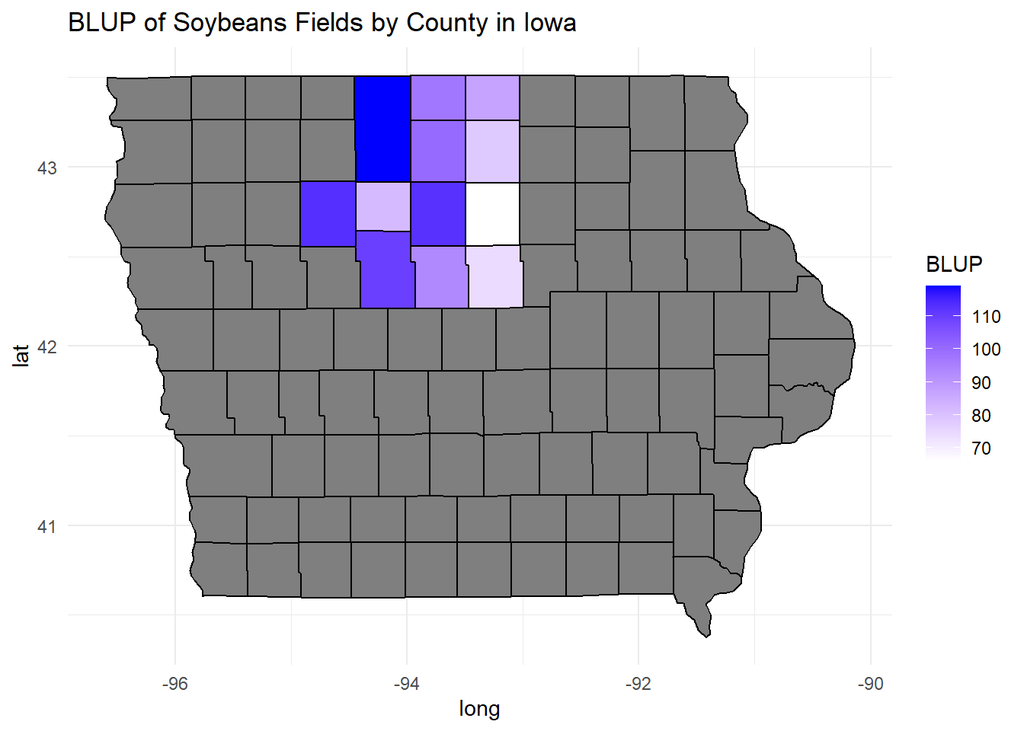

```r
iowa_map <- map_data("county", region = "iowa")


iowa_map <- iowa_map %>%
  rename(CountyName = subregion)


results$corn$CountyName <- tolower(results$corn$CountyName)
results$soybeans$CountyName <- tolower(results$soybeans$CountyName)

corn.blup.y <- results$corn %>%
  rename(mu_gamma_corn = mu_gamma, mu_bar_y_corn = mu_bar_y) %>% select(CountyName, mu_gamma_corn, mu_bar_y_corn)

soybeans.blup.y <- results$soybeans %>%
  rename(mu_gamma_soybeans = mu_gamma, mu_bar_y_soybeans = mu_bar_y) %>% select(CountyName, mu_gamma_soybeans, mu_bar_y_soybeans)


map_data <- left_join(iowa_map, corn.blup.y, by = c("CountyName"))
map_data <- left_join(map_data, soybeans.blup.y, by = c("CountyName"))


ggplot(map_data, aes(x = long, y = lat,group = group, fill = mu_gamma_soybeans)) +
  geom_polygon(color = "black") +
  scale_fill_gradient(low = "white", high = "blue", na.value = "grey50") +
  labs(fill = "BLUP", title = "BLUP of Soybeans Fields by County in Iowa")+
  theme_minimal()
```

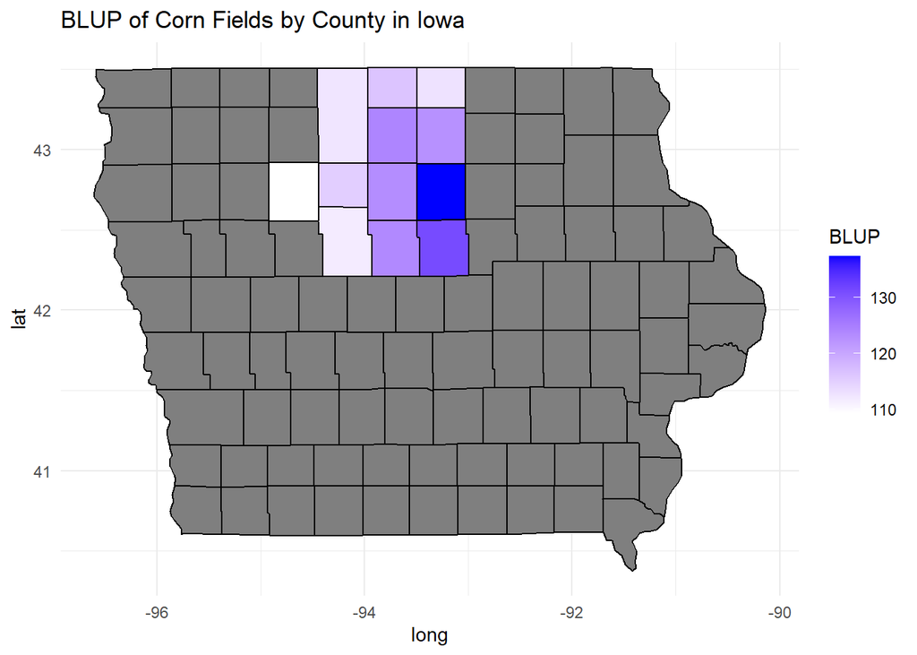

```r
ggplot(map_data, aes(x = long, y = lat,group = group, fill = mu_gamma_corn)) +
  geom_polygon(color = "black") +
  scale_fill_gradient(low = "white", high = "blue", na.value = "grey50") +
  labs(fill = "BLUP", title = "BLUP of Corn Fields by County in Iowa")+
  theme_minimal()
```

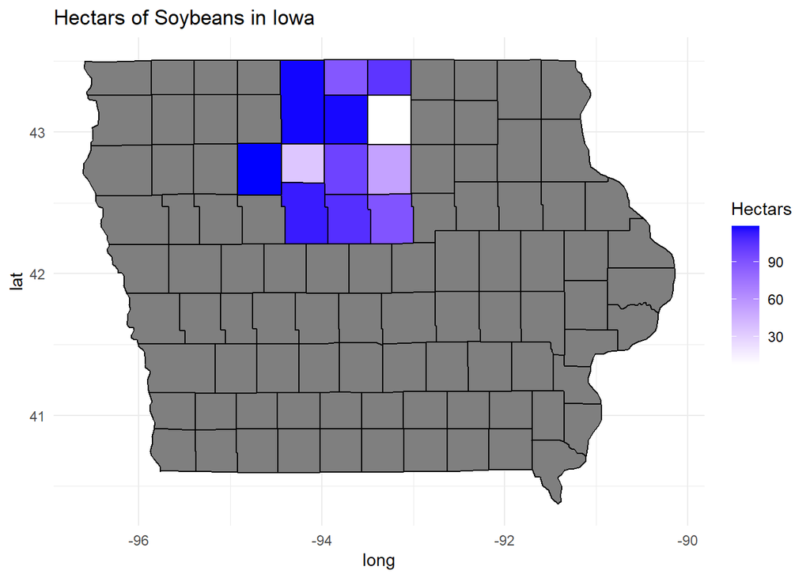

```r
ggplot(map_data, aes(x = long, y = lat,group = group, fill = mu_bar_y_soybeans)) +
  geom_polygon(color = "black") +
  scale_fill_gradient(low = "white", high = "blue", na.value = "grey50") +
  labs(fill = "Hectars", title = "Hectars of Soybeans in Iowa")+
  theme_minimal()
```

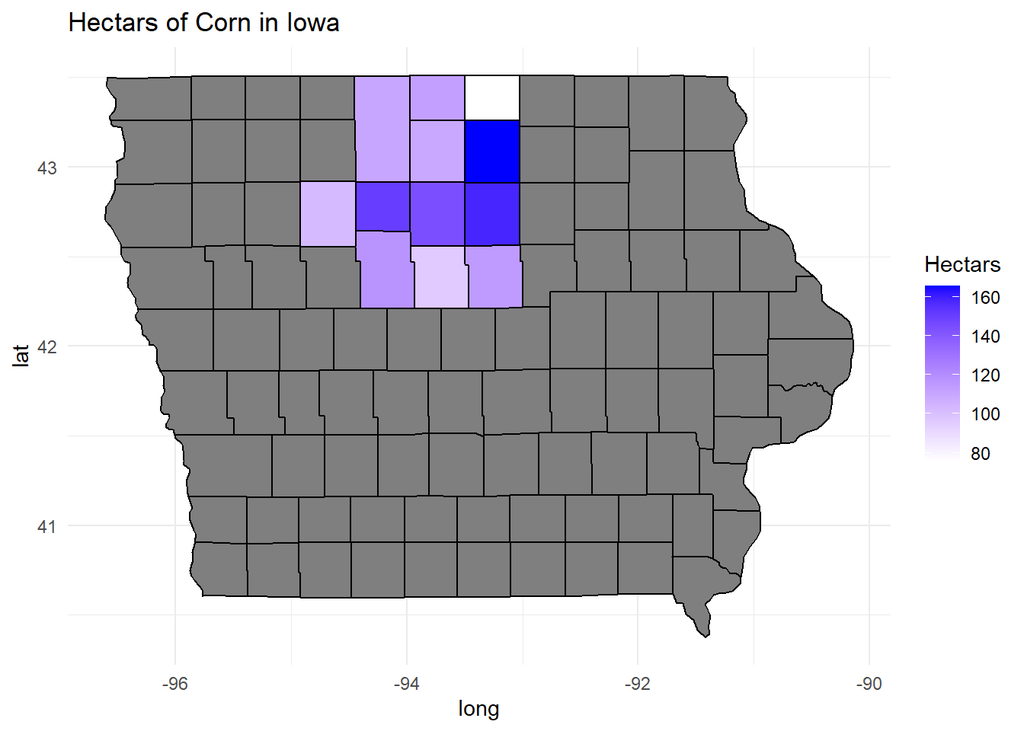

```r
ggplot(map_data, aes(x = long, y = lat,group = group, fill = mu_bar_y_corn)) +
  geom_polygon(color = "black") +
  scale_fill_gradient(low = "white", high = "blue", na.value = "grey50") +
  labs(fill = "Hectars", title = "Hectars of Corn in Iowa")+
  theme_minimal()
```

There seems to be a very high negative correlation between soybeans and corns!

## Principal component analysis

#### Dataset

The dataset iris is a classical dataset in statistics, and has been already analysed in Fisher, R. A. (1936) The use of multiple measurements in taxonomic problems. Annals of Eugenics, 7, Part II, 179-188. It contains the following variables, all measured in centimeters:

- Sepal.Length: length of the sepal
- Sepal.Width: width of the sepal
- Petal.Length: length of the petal
- Petal.Width: width of the petal
- Species: type of the iris: setosa, versicolor, or virginic

There are 50 flowers from each of the three species. All measures are in centimeters. The dataset is accessible automatically in R; try ?iris. We shall use principal component analysis for visualisation of the data and K-means classification. In R, this can be done with the functions prcomp and kmeans.

1-) Create a reduced dataset discarding the Species. Calculate loadings and scores for the reduced dataset using the empirical covariance matrix. What proportion of total variation in the data is explained by the first two principal components? Interpret the first two principal components.

```r
data(iris)

iris_reduced <- iris[, -5]

perform.pca_.firsttwo <- function(data, scale = FALSE) {

  pca_result <- prcomp(data, scale. = scale)

  loadings <- pca_result$rotation

  scores <- pca_result$x

  explained_variance <- summary(pca_result)$importance[2, ]

  proportion_variance_explained <- explained_variance[1:2]

  return(proportion_variance_explained)
}

print(perform.pca_.firsttwo(iris_reduced))
```

```
##     PC1     PC2
## 0.92462 0.05307
```

The first principal component (PC1) explains approximately 92.46% of the total variance in the dataset. The second principal component (PC2) explains approximately 5.31% of the total variance. Together, the first two principal components explain about 97.77% of the total variance in the dataset.

2-) Do the same, now using the empirical correlation matrix. Are the results similar?

```r
print(perform.pca_.firsttwo(iris_reduced, TRUE))
```

```
##     PC1     PC2
## 0.72962 0.22851
```

3-) Create a new dataset where the petal length is measured in millimetres instead of centimetres. Have the principal components and proportion of variance explained changed when using the covariance matrix? And when using the correlation matrix?

```r
iris_mm <- iris[, -5]
iris_mm$Petal.Length <- iris_mm$Petal.Length * 10

print(perform.pca_.firsttwo(iris_mm))
```

```
##     PC1     PC2
## 0.99884 0.00081
```

```r
print(perform.pca_.firsttwo(iris_mm, TRUE))
```

```
##     PC1     PC2
## 0.72962 0.22851
```

After transforming Petal Length to millimeters, PC1 explains 99.88% of the total variance, while PC2 explains only 0.08%. The significant change when using the covariance matrix indicates that the variance is dominated by the Petal Length, as its scale has increased tenfold. This causes the first principal component to capture almost all the variance, leaving very little for the second component.The proportions of variance explained by the first two principal components remain almost unchanged when using the correlation matrix. This is because the correlation matrix standardizes the data, making it invariant to changes in the scale of individual variables. The results are consistent regardless of whether Petal Length is measured in centimeters or millimeters.

4-) Henceforth use the original dataset (with all measurements in centimetres) and the covariance matrix. Plot the first two principal components against each other, marking the different species by colour. What do you observe? Would you expect that this two-dimensional plot of the data give a reasonable representation of the relative position of the observations in the original four-dimensional space?

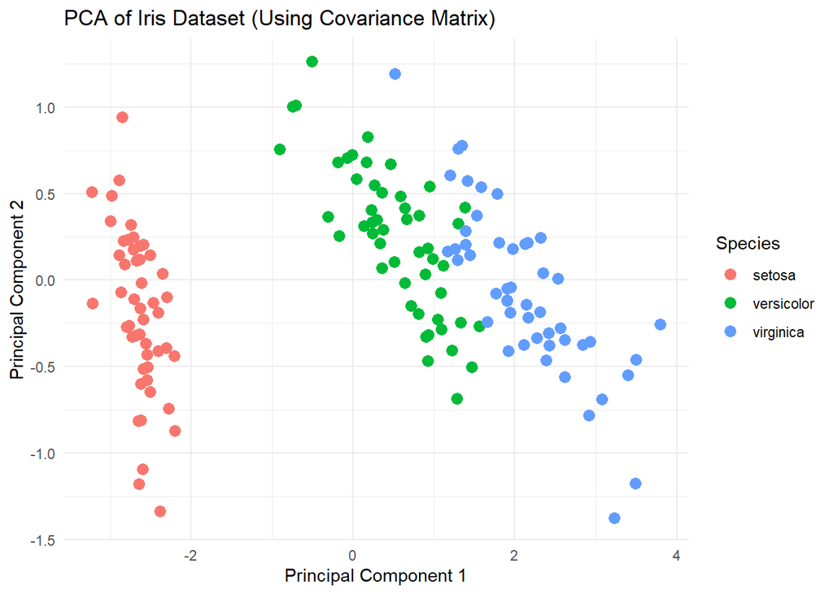

```r
pca_cov <- prcomp(iris_reduced, scale. = FALSE)
pca_data <- data.frame(PC1 = pca_cov$x[, 1], PC2 = pca_cov$x[, 2], Species = iris$Species)

# Plot the first two principal components
ggplot(pca_data, aes(x = PC1, y = PC2, color = Species)) +
  geom_point(size = 3) +
  labs(title = "PCA of Iris Dataset (Using Covariance Matrix)",
       x = "Principal Component 1",
       y = "Principal Component 2") +
  theme_minimal()
```

5-) Perform K-means clustering for the first two principal components obtained in (a) with K = 3 and using set.seed(47) (the output algorithm depends quite heavily on the seed). Do clusters coincide with the iris species? What is the classification error? Note that you may need to relabel ”by hand” the result in kmeans(…)$cluster when comparing it with the variable Species. The latter needs to be converted into an integer. Is the classification error when using the entire dataset much smaller?

```r
set.seed(47)

# Perform K-means clustering on the first two principal components
kmeans_result <- kmeans(pca_data[, c("PC1", "PC2")], centers = 3)

# Add the cluster results to the data frame
pca_data$Cluster <- kmeans_result$cluster
species_int <- as.integer(pca_data$Species)

print(table(pca_data$Cluster, species_int))
```

```
##    species_int
##      1  2  3
##   1 18  4  0
##   2  0 46 50
##   3 32  0  0
```

```r
cluster_to_species <- c(2, 3, 1)
relabeled_clusters <- cluster_to_species[pca_data$Cluster]
table(relabeled_clusters, species_int)
```

```
##                   species_int
## relabeled_clusters  1  2  3
##                  1 32  0  0
##                  2 18  4  0
##                  3  0 46 50
```

```r
1-mean(relabeled_clusters != species_int)
```

```
## [1] 0.5733333
```

## Time Series

#### Dataset

Access the cmort dataset from the astsa package. The data contains the weekly cardiovascular mortality in Los Angeles County from 1970 to 1979 from following study: Shumway, R.H. (1988). Applied statistical time series analysis. Prentice-Hall, Englewood Cliffs

#### Exercises

1-) Fit an AR(2) to the data using linear regression as in the example on the Recruitment data presented in the lecture.

```r
data("cmort")

df <- data.frame(matrix(NA, ncol=3, nrow=(length(cmort)-2)))
names(df) <- c("x", "x_1", "x_2")

for (i in 1:(n-2)) {
  df[i, ] <- cmort[c(i, i+1, i+2)]
}

ar.model.cmort <- lm(x ~ x_1 + x_2, data=df)
summary(ar.model.cmort)
```

```
##
## Call:
## lm(formula = x ~ x_1 + x_2, data = df)
##
## Residuals:
##     Min      1Q  Median      3Q     Max
## -18.179  -4.042  -0.079   3.716  19.255
##
## Coefficients:
##             Estimate Std. Error t value Pr(>|t|)
## (Intercept) 11.10996    2.41007    4.61 5.12e-06 ***
## x_1          0.43117    0.03998   10.79  < 2e-16 ***
## x_2          0.44394    0.04007   11.08  < 2e-16 ***
## ---
## Signif. codes:  0 '***' 0.001 '**' 0.01 '*' 0.05 '.' 0.1 ' ' 1
##
## Residual standard error: 5.716 on 503 degrees of freedom
##   (492 observations deleted due to missingness)
## Multiple R-squared:  0.6757, Adjusted R-squared:  0.6744
## F-statistic: 524.1 on 2 and 503 DF,  p-value: < 2.2e-16
```

2-) Use the estimated coefficients from (a) to forecast the following 4 weeks together with a 95%-CI.

```r
coef <- ar.model.cmort$coefficients

forecasts <- numeric(4)
forecast_se <- numeric(4)
last_values <- tail(cmort, 2)

for (i in 1:4) {
  forecasts[i] <- coef[1] + coef[2] * last_values[2] + coef[3] * last_values[1]

  last_values <- c(last_values[2], forecasts[i])

  forecast_se[i] <- sqrt(sum(residuals(ar.model.cmort)^2) / (n-2))
}

alpha <- 0.05
z <- qnorm(1 - alpha / 2)
forecast_lower <- forecasts - z * forecast_se
forecast_upper <- forecasts + z * forecast_se

forecast_df <- data.frame(
  Week = (n + 1):(n + 4),
  Forecast = forecasts,
  Lower_CI = forecast_lower,
  Upper_CI = forecast_upper
)

print(forecast_df)
```

```
##   Week Forecast Lower_CI Upper_CI
## 1 1001 87.67186 79.71885 95.62487
## 2 1002 86.86349 78.91049 94.81650
## 3 1003 87.48356 79.53055 95.43657
## 4 1004 87.39205 79.43904 95.34506
```

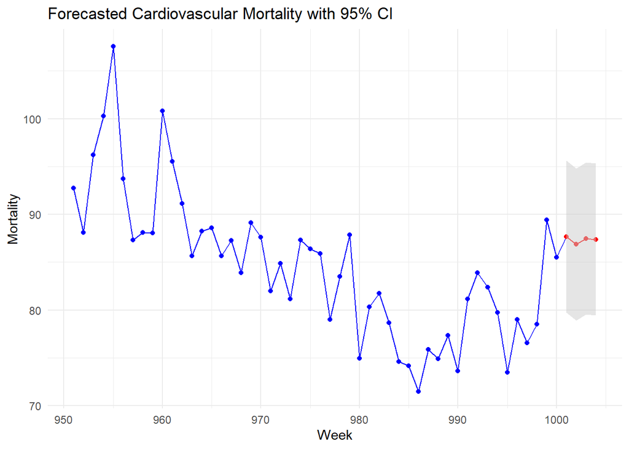

```r
# Prepare data for plotting
plot_data <- data.frame(
  Week = (n-49):(n+4),
  Mortality = c(tail(cmort, 50), forecasts),
  Forecast = c(rep(NA, 50), forecasts),
  Lower_CI = c(rep(NA, 50), forecast_lower),
  Upper_CI = c(rep(NA, 50), forecast_upper)
)

# Plot the data
ggplot(plot_data, aes(x = Week, y = Mortality)) +
  geom_line(color = "blue") +
  geom_point(color = "blue") +
  geom_line(aes(y = Forecast), color = "red") +
  geom_point(aes(y = Forecast), color = "red") +
  geom_ribbon(aes(ymin = Lower_CI, ymax = Upper_CI), fill = "grey80", alpha = 0.5) +
  labs(title = "Forecasted Cardiovascular Mortality with 95% CI",
       x = "Week",
       y = "Mortality") +
  theme_minimal()
```

3-) Now use the Yule-Walker method to estimate the model. Compare the estimates and standard errors of the coefficients from the Yule-Walker method to the results from 1.

```r
acf_vals <- acf(cmort, plot = FALSE, type = "covariance")$acf[1:3]
gamma0 <- acf_vals[1]
gamma1 <- acf_vals[2]
gamma2 <- acf_vals[3]

# Yule-Walker equations
R <- matrix(c(1, gamma1/gamma0, gamma1/gamma0, 1), nrow = 2)
r <- c(gamma1/gamma0, gamma2/gamma0)
phi <- solve(R, r)
phi1_yw <- phi[1]
phi2_yw <- phi[2]

# Calculate the variance of the white noise process
sigma2_yw <- gamma0 * (1 - (phi1_yw * gamma1/gamma0 + phi2_yw * gamma2/gamma0))

# Calculate the standard errors of the coefficients
n <- length(cmort)

# Or we can use the R function ar.yw
cmort_yw <- ar.yw(cmort, order = 2)
cat("phi1 =", cmort_yw$ar[1], "\n")
```

```
## phi1 = 0.4339481
```

```r
cat("phi2 =", cmort_yw$ar[2], "\n")
```

```
## phi2 = 0.4375768
```

```r
se_phi <- sqrt(diag(cmort_yw$asy.var.coef))

# Print results
cat("Yule-Walker Estimates:\n")
```

```
## Yule-Walker Estimates:
```

```r
cat("phi1 =", phi1_yw, "\n")
```

```
## phi1 = 0.4339481
```

```r
cat("phi2 =", phi2_yw, "\n")
```

```
## phi2 = 0.4375768
```

```r
cat("Standard error:\n")
```

```
## Standard error:
```

```r
cat("se_phi =", se_phi, "\n")
```

```
## se_phi = 0.04001303 0.04001303
```

```r
coef_lm <- ar.model.cmort$coefficients
se_lm <- summary(ar.model.cmort)$coefficients[, "Std. Error"]

cat("\nLinear Regression Estimates (from part a):\n")
```

```
##
## Linear Regression Estimates (from part a):
```

```r
cat("phi1 =", coef_lm[2], "\n")
```

```
## phi1 = 0.4311677
```

```r
cat("phi2 =", coef_lm[3], "\n")
```

```
## phi2 = 0.443938
```

```r
cat("Standard errors:\n")
```

```
## Standard errors:
```

```r
cat("se_phi1 =", se_lm[2], "\n")
```

```
## se_phi1 = 0.03997701
```

```r
cat("se_phi2 =", se_lm[3], "\n")
```

```
## se_phi2 = 0.04007416
```

4-) Predict the following 4 weeks using the estimations from the Yule-Walker method. 5-) Compare the estimated standard errors of the coefficients obtained by linear regression with their corresponding asymptotic approximations as given by the asymptotic distribution of the estimators on the slides.

```r
forecasts_yw <- numeric(4)
last_values_yw <- tail(cmort, 2)

# Perform the forecasts
for (i in 1:4) {
  forecasts_yw[i] <- phi1_yw * last_values_yw[2] + phi2_yw * last_values_yw[1]
  last_values_yw <- c(last_values_yw[2], forecasts_yw[i])
}

forecast_lower_yw <- forecasts_yw - z * se_phi
forecast_upper_yw <- forecasts_yw + z * se_phi

# Create the forecast dataframe for Yule-Walker
forecast_df_yw <- data.frame(
  Week = (n + 1):(n + 4),
  Forecast = forecasts_yw,
  Lower_CI = forecast_lower_yw,
  Upper_CI = forecast_upper_yw
)

print(forecast_df_yw)
```

```
##   Week Forecast Lower_CI Upper_CI
## 1  509 76.23072 76.15229 76.30914
## 2  510 70.48862 70.41019 70.56704
## 3  511 63.94519 63.86677 64.02362
## 4  512 58.59308 58.51465 58.67150
```

```r
# Calculate asymptotic variance-covariance matrix
asymptotic_var_cov_matrix <- (solve(R) * sigma2_yw / n) / gamma0
se_phi_yw_asymptotic <- sqrt(asymptotic_var_cov_matrix[1, 1])

cat("se_phi_yw_asymptotic =", se_phi_yw_asymptotic, "\n")
```

```
## se_phi_yw_asymptotic = 0.03989471
```

The estimated standard errors from linear regression (0.03998 and 0.04007) are very close to the Yule-Walker standard errors (0.04001 and 0.04001).

6-) Try to fit an ARMA(2,2) model to the data. Does the more complex model provides a better fit or is an AR(2) model enough?

```r
ar.ols(cmort, order=2, demean=FALSE, intercept=TRUE)
```

```
##
## Call:
## ar.ols(x = cmort, order.max = 2, demean = FALSE, intercept = TRUE)
##
## Coefficients:
##      1       2
## 0.4286  0.4418
##
## Intercept: 11.45 (2.394)
##
## Order selected 2  sigma^2 estimated as  32.32
```

```r
arima(cmort, order = c(2, 0, 2))
```

```
##
## Call:
## arima(x = cmort, order = c(2, 0, 2))
##
## Coefficients:
##          ar1     ar2     ma1      ma2  intercept
##       0.3970  0.4857  0.0217  -0.0548    88.8732
## s.e.  0.1657  0.1572  0.1740   0.0982     2.0340
##
## sigma^2 estimated as 32.33:  log likelihood = -1604.38,  aic = 3220.77
```

The ARMA model results in different estimates and larger standard errors due to the inclusion of moving average terms, highlighting how additional parameters can influence the estimates and their precision. However, the moving average coefficients are close to zero, indicating that they do not significantly contribute to the estimation.

## References

1. McCullagh, P., & Nelder, J. A. (1989). *Generalized Linear Models*. Chapman and Hall/CRC.
2. Shumway, R. H. (2000). *Time Series Analysis and Its Applications*. Springer.
3. Finding the maximum likelihood estimator. Retrieved from [Math Stack Exchange](https://math.stackexchange.com/questions/240496/finding-the-maximum-likelihood-estimator).
4. Condition number. Retrieved from [Illinois Engineering](https://courses.engr.illinois.edu/cs357/sp2024/notes/ref-10-condition.html).
5. Cause of a high condition number in a Python statsmodels regression. Retrieved from [Stack Exchange](https://stats.stackexchange.com/questions/243000/cause-of-a-high-condition-number-in-a-python-statsmodels-regression#comment462188_243000).